# Timing genomic Testing Adoption

Load libraries

```r
options(warn=-1)
library(tidyverse)
library(bigrquery)
library(lubridate)
library(statar)
library(knitr)
library(stringi)
library(broom)
library(ggrepel)
library(ggfortify)

folder <- "C:/Users/victorf2"
#folder <- "C:/Users/victo"

setwd(paste0(folder, "/Box/dairy_matching/code/AISS data"))
```

# NAAB Info dataset

```r
bq_auth(email = "victorf2@illinois.edu")

projectid <- "dairy-168114"
query <- "
SELECT
    reg_id,
    id_number,
    breed,
    country,
    primary_naab_code,
    naab_codes,
    reg_name,
    birthdate,
    semen_release_date,
    genotype_information,
    sire_breed,
    sire_country,
    sire_id_number,
    dam_breed,
    dam_country,
    dam_id_number,
    mgs_breed,
    mgs_country,
    mgs_id_number,
    status
FROM
    CDCB_data.NAAB_Info
"

naab <- bq_project_query(projectid, query)
naab <- bq_table_download(naab)

naab <- naab |>
  mutate(birthdate = mdy(birthdate),
         yob = year(birthdate))

naab <- naab |>
  mutate(id_number = stringr::str_replace(id_number, "\\.", ""),
         id_number = str_pad(id_number, width = 12, side = "left", pad = "0"),
         reg_id = paste0(breed, country, id_number))
```

```r
naab <- naab |>
  mutate(sire_id_number = stringr::str_replace(sire_id_number, "\\.", ""),
         sire_id_number = str_pad(sire_id_number, width = 12, side = "left", pad = "0"),
         sire_id = paste0(sire_breed, sire_country, sire_id_number))

naab$sire_id <- replace(naab$sire_id, naab$sire_id == "NANANA", NA)

naab <- naab |>
  mutate(mgs_id_number = stringr::str_replace(mgs_id_number, "\\.", ""),
         mgs_id_number = str_pad(mgs_id_number, width = 12, side = "left", pad = "0"),
         mgs_id = paste0(mgs_breed, mgs_country, mgs_id_number))

naab$mgs_id <- replace(naab$mgs_id, naab$mgs_id == "NANANA", NA)

naab <- naab |>
  mutate(dam_id_number = stringr::str_replace(dam_id_number, "\\.", ""),
         dam_id_number = str_pad(dam_id_number, width = 12, side = "left", pad = "0"),
         dam_id = paste0(dam_breed, dam_country, dam_id_number))

naab$dam_id <- replace(naab$dam_id, naab$dam_id == "NANANA", NA)
```

# AISS data

```r
query <- "SELECT
  country,
  id_number,
  name,
  primary_stud_code,
  sire_id,
  mgs_id,
  period,
  status,
  breed,
  naab_code,
  pta_milk as pta_milk,
  pta_fat_lb as pta_fat_lb,
  pta_protein_lb as pta_protein_lb,
  pta_scs as pta_scs,
  pta_pl as pta_pl,
  pta_dpr as pta_dpr,
  pta_hcr as pta_hcr,
  pta_ccr as pta_ccr,
  pta_liv as pta_liv,
  pta_ssb as pta_ssb,
  pta_dsb as pta_dsb,
  pta_type as pta_type,
  pta_stature as pta_stature,
  pta_strength as pta_strength,
  pta_body_depth as pta_body_depth,
  pta_dairy_form as pta_dairy_form,
  pta_rump_angle as pta_rump_angle,
  pta_thurl_width as pta_thurl_width,
  pta_rear_legs_side as pta_rear_legs_side,
  pta_rear_legs_rear as pta_rear_legs_rear,
  pta_foot_angle as pta_foot_angle,
  pta_foot_leg_score as pta_foot_leg_score,
  pta_fore_udder as pta_fore_udder,
  pta_rear_udder_height as pta_rear_udder_height,
  pta_rear_udder_width as pta_rear_udder_width,
  pta_udder_cleft as pta_udder_cleft,
  pta_udder_depth as pta_udder_depth,
  pta_teat_front_place as pta_teat_front_place,
  pta_teat_rear_place as pta_teat_rear_place,
  pta_teat_length as pta_teat_length,
  pta_mobility,
  pta_gest_length as pta_gest_length,
  pta_ketosis as pta_ketosis,
  pta_metritis as pta_metritis,
  pta_mastitis as pta_mastitis,
  pta_milk_fever as pta_milk_fever,
  FM as FM,
  CM as CM,
  GM as GM,
  NM as NM,
  TPI,
  udder_composite,
  body_weight_composite,
  feet_legs_composite,
  aaa_rating,
  daughts_in_milk_pta,
  dob,
  semen_price
FROM
  CDCB_data.NAAB_AISS
"

naab_aiss <- bq_project_query(projectid, query)
naab_aiss <- bq_table_download(naab_aiss)

naab_aiss <- naab_aiss %>%
  separate(period, into = c("year", "per_num"), sep = "-", remove = FALSE) |>
  mutate(dob = ymd(dob),
         yob = year(dob))

naab_aiss <- naab_aiss |>
  mutate(id_number = stringr::str_replace(id_number, "\\.", ""),
         id_number = str_pad(id_number, width = 12, side = "left", pad = "0"),
         reg_id = paste0(breed, country, id_number))
```

# Characterizing “missing” status animals

1. National origin

```r
naab_aiss |>
  filter(is.na(status)) |>
  tab(country)
```

```
##
## country │    Freq.  Percent     Cum.
## ────────┼────────────────────────────
##     840 │       91     2.06     2.06
##     AUS │        9     0.20     2.27
##     CAN │     1236    28.01    30.28
##     CHE │        8     0.18    30.46
##     CZE │        4     0.09    30.55
##     DEU │       46     1.04    31.60
##     DNK │       27     0.61    32.21
##     FRA │       21     0.48    32.68
##     GBR │        8     0.18    32.86
##     HUN │       32     0.73    33.59
##     ITA │        4     0.09    33.68
##     NLD │       98     2.22    35.90
##     NZL │      318     7.21    43.11
##     USA │     2510    56.89   100.00
```

2. Number of daughters

```r
naab_aiss |>
  filter(is.na(status)) |>
  group_by(country) |>
  filter(daughts_in_milk_pta != 99999) |>
  summarise(daught = max(daughts_in_milk_pta, na.rm = TRUE),  N = n())
```

| country | daught | N |
| --- | --- | --- |
| 840 | 1400 | 91 |
| AUS | 97727 | 9 |
| CAN | 76169 | 1233 |
| CHE | 12985 | 8 |
| CZE | 217 | 4 |
| DEU | 29439 | 46 |
| DNK | 32002 | 27 |
| FRA | 1027 | 7 |
| GBR | 1687 | 8 |
| HUN | 21838 | 32 |

[output cut: 4 more lines]

3. Age

```r
naab_aiss |>
  mutate(period = ym(period),
         year = year(period),
         age = year-yob) ->
  naab_aiss
```

Active and Foreign bulls show up first at ages 4 or 5, genomic bulls at age 1.

```r
kable(table1)
```

| age | G | A | F |
| --- | --- | --- | --- |
| 0 | 92 | NA | NA |
| 1 | 9517 | 1 | NA |
| 2 | 4338 | NA | NA |
| 3 | 720 | NA | NA |
| 4 | 253 | 382 | 38 |
| 5 | 71 | 2723 | 754 |
| 6 | 7 | 1018 | 670 |
| 7 | 2 | 263 | 319 |
| 8 | NA | 173 | 221 |
| 9 | NA | 115 | 106 |
| 10 | NA | 85 | 66 |
| 11 | NA | 53 | 28 |
| 12 | NA | 29 | 17 |
| 13 | NA | 22 | 11 |
| 14 | NA | 11 | 5 |
| 15 | NA | 9 | 1 |
| 16 | NA | 2 | NA |
| 17 | NA | 1 | NA |
| 18 | NA | 1 | 2 |
| 24 | NA | NA | 1 |

Fill out missing values with last missing status

```r
naab_aiss|>
  group_by(reg_id) |>
  fill(status, .direction = "down") |>
  ungroup() ->
  naab_aiss
```

Status by year of proof

```r
naab_aiss |>
  mutate(year_proof = year(period)) ->
  naab_aiss
```

```r
kable(table2)
```

| year_proof | A | F | G |
| --- | --- | --- | --- |
| 2000 | 3676 | 761 | NA |
| 2001 | 3233 | 720 | NA |
| 2002 | 3553 | 650 | NA |
| 2003 | 3487 | 702 | NA |
| 2004 | 3383 | 746 | NA |
| 2005 | 3297 | 687 | NA |
| 2006 | 3525 | 793 | NA |
| 2007 | 2729 | 578 | NA |
| 2008 | 3006 | 738 | NA |
| 2009 | 2951 | 849 | NA |
| 2010 | 3732 | 1354 | 1774 |
| 2011 | 2923 | 1336 | 2789 |
| 2012 | 2886 | 1310 | 3654 |
| 2013 | 2905 | 1255 | 4806 |
| 2014 | 2885 | 1243 | 5831 |
| 2015 | 2689 | 1219 | 6347 |
| 2016 | 2646 | 1071 | 8009 |
| 2017 | 2532 | 901 | 8016 |
| 2018 | 2210 | 1182 | 9202 |
| 2019 | 2113 | 1394 | 9850 |
| 2020 | 2325 | 1856 | 10811 |
| 2021 | 1926 | 1525 | 7538 |

Status by year of birth

```r
kable(table3)
```

| age | A | F | G |
| --- | --- | --- | --- |
| 0 | NA | NA | 92 |
| 1 | 3 | NA | 15592 |
| 2 | 3 | NA | 28777 |
| 3 | 26 | NA | 19802 |
| 4 | 2627 | 239 | 10386 |
| 5 | 12151 | 2956 | 2769 |
| 6 | 14109 | 5094 | 749 |
| 7 | 10389 | 4610 | 264 |
| 8 | 7527 | 3626 | 117 |
| 9 | 5577 | 2413 | 51 |
| 10 | 3975 | 1502 | 21 |
| 11 | 2767 | 967 | 5 |

Year of proof and age by status

**Question**: What is the valid comparison? Let $t$ be the year of birth of a bull. 1. $genomic_{t}$ vs $active_{t}$ 2. $genomic_{t}$ vs $active_{t-5}$

```r
kable(genomic_age)
```

| age | 2010 | 2011 | 2012 | 2013 | 2014 | 2015 | 2016 | 2017 | 2018 | 2019 | 2020 | 2021 |
| --- | --- | --- | --- | --- | --- | --- | --- | --- | --- | --- | --- | --- |
| 0 | 1 | 1 | NA | NA | 3 | 1 | 9 | 14 | 24 | 26 | 13 | NA |
| 1 | 432 | 661 | 673 | 954 | 1250 | 1307 | 1909 | 1564 | 1982 | 1706 | 2169 | 985 |
| 2 | 774 | 1080 | 1639 | 1717 | 2291 | 2541 | 2654 | 3237 | 3129 | 3921 | 3163 | 2631 |
| 3 | 337 | 665 | 879 | 1394 | 1294 | 1598 | 2098 | 1819 | 2581 | 2195 | 3229 | 1713 |
| 4 | 188 | 318 | 386 | 595 | 789 | 674 | 975 | 999 | 1084 | 1464 | 1414 | 1500 |
| 5 | 40 | 59 | 66 | 118 | 171 | 184 | 262 | 248 | 308 | 345 | 569 | 399 |
| 6 | 2 | 4 | 10 | 21 | 26 | 38 | 59 | 99 | 42 | 124 | 141 | 183 |
| 7 | NA | 1 | 1 | 7 | 4 | NA | 31 | 27 | 46 | 19 | 63 | 65 |
| 8 | NA | NA | NA | NA | 3 | 3 | 4 | 8 | 3 | 44 | 18 | 34 |
| 9 | NA | NA | NA | NA | NA | 1 | 7 | 1 | 3 | 3 | 26 | 10 |
| 10 | NA | NA | NA | NA | NA | NA | 1 | NA | NA | 3 | 3 | 14 |
| 11 | NA | NA | NA | NA | NA | NA | NA | NA | NA | NA | 3 | 2 |
| 12 | NA | NA | NA | NA | NA | NA | NA | NA | NA | NA | NA | 2 |

```r
kable(active_age)
```

| age | 2005 | 2006 | 2007 | 2008 | 2009 | 2010 | 2011 | 2012 | 2013 | 2014 | 2015 | 2016 | 2017 | 2018 | 2019 | 2020 | 2021 |
| --- | --- | --- | --- | --- | --- | --- | --- | --- | --- | --- | --- | --- | --- | --- | --- | --- | --- |
| 1 | NA | NA | NA | NA | NA | NA | 3 | NA | NA | NA | NA | NA | NA | NA | NA | NA | NA |
| 2 | NA | NA | NA | NA | NA | NA | NA | 3 | NA | NA | NA | NA | NA | NA | NA | NA | NA |
| 3 | NA | NA | NA | NA | NA | NA | NA | 1 | 3 | NA | 1 | 4 | 1 | 2 | NA | 12 | 2 |
| 4 | 31 | 16 | 6 | 2 | 8 | 95 | 83 | 126 | 165 | 229 | 206 | 241 | 328 | 215 | 343 | 225 | 189 |
| 5 | 484 | 649 | 391 | 403 | 374 | 517 | 514 | 468 | 579 | 636 | 708 | 636 | 668 | 661 | 490 | 770 | 487 |
| 6 | 713 | 798 | 666 | 662 | 707 | 785 | 541 | 544 | 480 | 568 | 457 | 598 | 451 | 477 | 451 | 389 | 490 |
| 7 | 529 | 611 | 510 | 569 | 511 | 602 | 478 | 452 | 411 | 358 | 364 | 301 | 345 | 268 | 302 | 319 | 221 |
| 8 | 502 | 414 | 382 | 419 | 428 | 471 | 332 | 363 | 342 | 267 | 217 | 227 | 191 | 173 | 154 | 191 | 187 |
| 9 | 349 | 369 | 235 | 328 | 298 | 416 | 249 | 248 | 270 | 223 | 171 | 151 | 133 | 115 | 104 | 106 | 98 |
| 10 | 235 | 238 | 209 | 197 | 216 | 295 | 219 | 180 | 204 | 177 | 142 | 110 | 106 | 72 | 86 | 80 | 60 |
| 11 | 176 | 144 | 123 | 168 | 130 | 168 | 171 | 144 | 121 | 137 | 109 | 118 | 79 | 63 | 47 | 81 | 45 |
| 12 | 119 | 114 | 68 | 96 | 122 | 139 | 103 | 120 | 98 | 82 | 107 | 78 | 71 | 45 | 37 | 38 | 50 |

# How old are bulls when they are proven for the first time?:

Genomic-tested bulls are proven mostly at ages 1 or 2, daughter-proven bulls wait until they are 4-6 years old. The average lifespan of a bovine is 10-12 years old https://livestock.extension.wisc.edu/articles/when-to-cull-bulls. We can assume that bulls 10 years and older are just frozen semen samples.

Other thing to note, we have 92 bulls tested before they reach one year of age.

```r
kable(table4)
```

| age_proof | A | F | G |
| --- | --- | --- | --- |
| 0 | NA | NA | 92 |
| 1 | 1 | NA | 9517 |
| 2 | NA | NA | 4339 |
| 3 | 17 | NA | 721 |
| 4 | 1861 | 191 | 254 |
| 5 | 3912 | 1355 | 71 |
| 6 | 1264 | 828 | 7 |
| 7 | 366 | 345 | 2 |
| 8 | 304 | 223 | NA |
| 9 | 255 | 113 | NA |
| 10 | 157 | 69 | NA |
| 11 | 106 | 30 | NA |
| 12 | 51 | 19 | NA |
| 13 | 37 | 12 | NA |
| 14 | 16 | 5 | NA |
| 15 | 9 | 1 | NA |
| 16 | 4 | NA | NA |
| 17 | 2 | NA | NA |
| 18 | 1 | 2 | NA |
| 24 | 1 | 1 | NA |

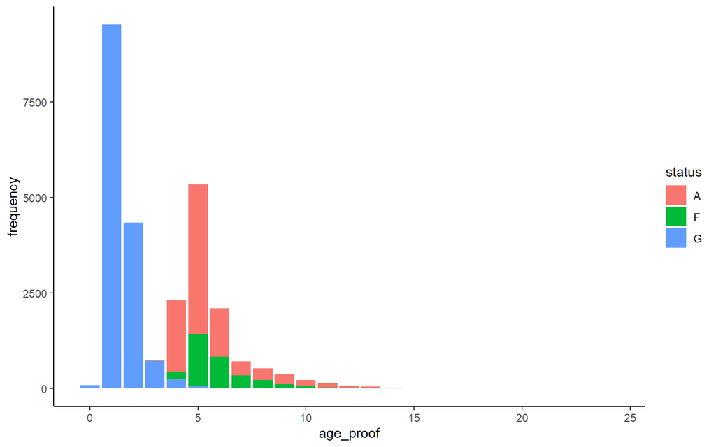

```r
age_proof_bulls |>
  rename(frequency = `Freq.`) |>
  select(c(status, age_proof, frequency)) |>
  ggplot(aes(x = age_proof, y = frequency, group = status)) +
  geom_bar(stat="identity", aes(fill = status)) +
  theme_classic()
```

The key period to look into is 2010-2015

```r
kable(first_proof)
```

| year | A | F | G |
| --- | --- | --- | --- |
| 2000 | 1156 | 277 | NA |
| 2001 | 217 | 92 | NA |
| 2002 | 391 | 114 | NA |
| 2003 | 249 | 92 | NA |
| 2004 | 251 | 92 | NA |
| 2005 | 254 | 71 | NA |
| 2006 | 298 | 114 | NA |
| 2007 | 237 | 69 | NA |
| 2008 | 325 | 214 | NA |
| 2009 | 312 | 118 | NA |
| 2010 | 333 | 246 | 903 |
| 2011 | 203 | 152 | 798 |
| 2012 | 155 | 109 | 844 |
| 2013 | 124 | 118 | 1071 |
| 2014 | 112 | 73 | 1265 |
| 2015 | 78 | 67 | 1317 |
| 2016 | 55 | 34 | 1623 |
| 2017 | 33 | 16 | 1289 |
| 2018 | 31 | 65 | 1712 |
| 2019 | 38 | 20 | 1446 |
| 2020 | 35 | 24 | 1617 |
| 2021 | 11 | 71 | 1118 |

CDN data

```r
cdn <- read.csv(paste0(folder, "/Box/Dairy Industry in US/Data/Network data/cdn_data.csv"))
naab_aiss <- inner_join(naab_aiss, cdn[c("reg_id_alt", "inbreeding", "relationship")], by = join_by(reg_id == reg_id_alt))
```

Genomic tested animals are on average more inbred than daughter-proven bulls.

```r
naab_aiss |>
  group_by(reg_id) |>
  arrange(year_proof) |>
  slice_tail(n = 1) |>
  ungroup() |>
  group_by(status) |>
  summarise(inb = mean(inbreeding, na.rm = TRUE),
            N = n())
```

| status | inb | N |
| --- | --- | --- |
| A | 6.554163 | 7444 |
| F | 5.609718 | 2024 |
| G | 9.753082 | 11191 |
| NA | 6.101583 | 259 |

```r
kable(inbreeding_year)
```

| yob | A | F | G |
| --- | --- | --- | --- |
| 2006 | 6.234800 | 6.466081 | 6.254021 |
| 2007 | 6.292248 | 5.861429 | 6.432842 |
| 2008 | 5.998965 | 6.361622 | 6.528974 |
| 2009 | 6.103371 | 6.531500 | 6.707223 |
| 2010 | 6.552051 | 5.700000 | 6.420055 |
| 2011 | 6.839355 | 4.887857 | 6.813559 |
| 2012 | 7.761923 | 4.077333 | 7.515179 |
| 2013 | 8.149200 | 4.807826 | 8.000730 |
| 2014 | 7.833415 | 5.104815 | 8.447690 |
| 2015 | 9.902143 | 5.250400 | 9.255717 |
| 2016 | 10.317692 | 5.385000 | 9.921886 |
| 2017 | 11.120000 | NA | 11.388001 |
| 2018 | NA | NA | 11.752563 |
| 2019 | NA | NA | 12.345264 |
| 2020 | NA | NA | 12.693947 |

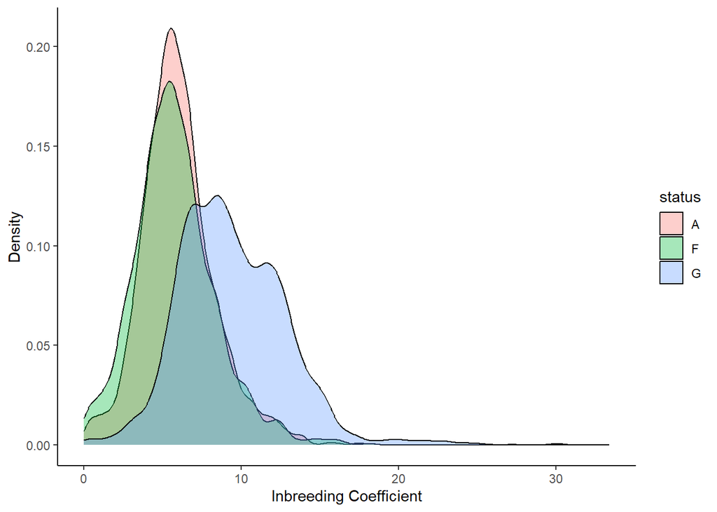

```r
naab_aiss |>
  filter(!is.na(status) & !is.na(inbreeding) & inbreeding > 0) |>
  group_by(reg_id) |>
  arrange(year_proof) |>
  slice_head(n = 1) |>
  ungroup() |>
  ggplot(aes(x = inbreeding, group = status)) +
  geom_density(aes(fill = status), alpha = 0.35) +
  theme_classic() +
  xlab("Inbreeding Coefficient") + ylab("Density")
```

Changes in Net Merit by type of proof and year of birth

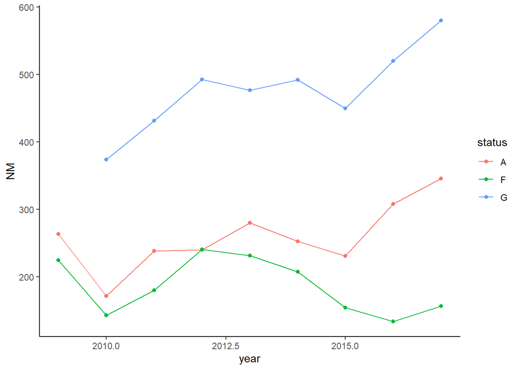

```r
naab_aiss |>
  group_by(reg_id) |>
  arrange(year_proof) |>
  slice_tail(n = 1) |>
  ungroup() |>
  filter(!is.na(status) & year > 2008 & year < 2018) |>
  group_by(year, status) |>
  summarise(NM = mean(NM, na.rm = TRUE)) |>
  #pivot_wider(id_cols = year, names_from = "status", values_from = "NM") |>
  ggplot(aes(x = year, y = NM, group = status)) +
  geom_line(aes(color = status)) +
  geom_point(aes(color = status)) +
  theme_classic()
```

Changes in TPI by type of proof and year of birth

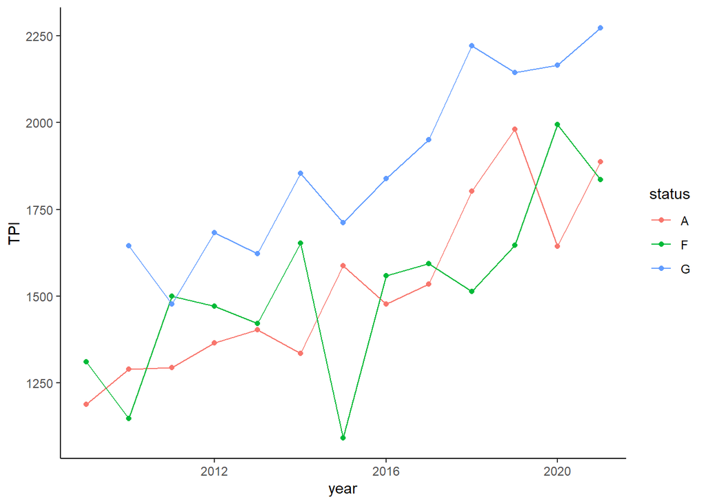

```r
naab_aiss |>
  group_by(reg_id) |>
  arrange(year_proof) |>
  slice_tail(n = 1) |>
  ungroup() |>
  filter(!is.na(status) & year > 2008) |>
  group_by(year, status) |>
  summarise(TPI = mean(TPI, na.rm = TRUE)) |>
  #pivot_wider(id_cols = year, names_from = "status", values_from = "NM") |>
  ggplot(aes(x = year, y = TPI, group = status)) +
  geom_line(aes(color = status)) +
  geom_point(aes(color = status)) +
  theme_classic()
```

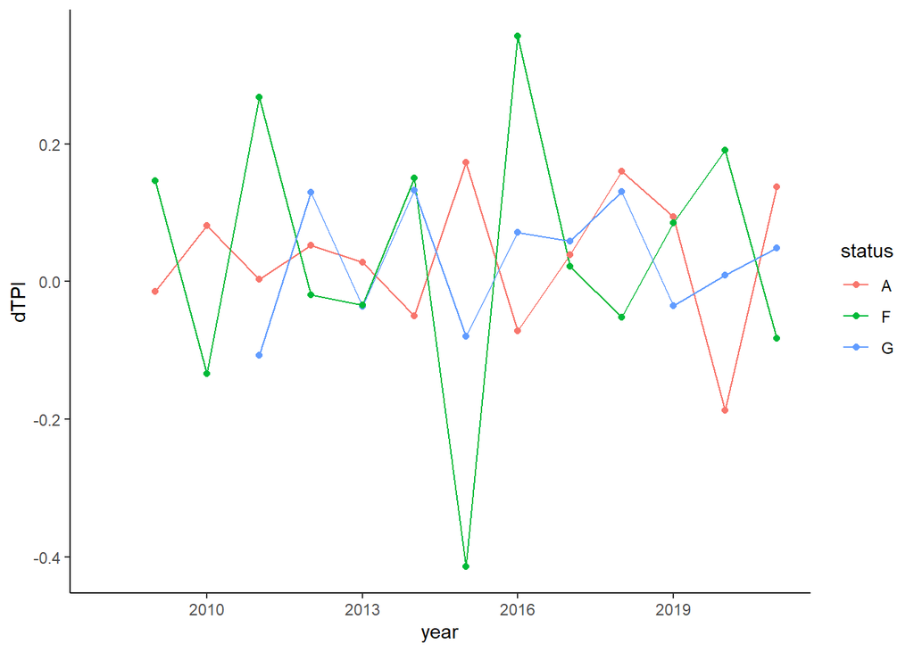

```r
naab_aiss |>
  group_by(reg_id) |>
  arrange(year_proof) |>
  slice_tail(n = 1) |>
  ungroup() |>
  filter(!is.na(status) & year > 2007) |>
  group_by(year, status) |>
  summarise(TPI = mean(TPI, na.rm = TRUE)) |>
  ungroup() |>
  pivot_wider(id_cols = year, names_from = "status", values_from = "TPI") |>
  mutate(A_1 = dplyr::lag(A, n = 1),
         F_1 = dplyr::lag(F, n = 1),
         G_1 = dplyr::lag(G, n = 1),
         dA = log(A)-log(A_1),
         dF = log(F)-log(F_1),
         dG = log(G)-log(G_1)) |>
  select(c(year, dA, dG, dF)) |>
  rename(A = dA, F = dF, G = dG) |>
  pivot_longer(cols = A:F, names_to = "status", values_to = "dTPI") |>
  ggplot(aes(x = year, y = dTPI, group = status)) +
  geom_line(aes(color = status)) +
  geom_point(aes(color = status)) +
  theme_classic()
```

Changes in Milk PTA by type of proof and year of birth

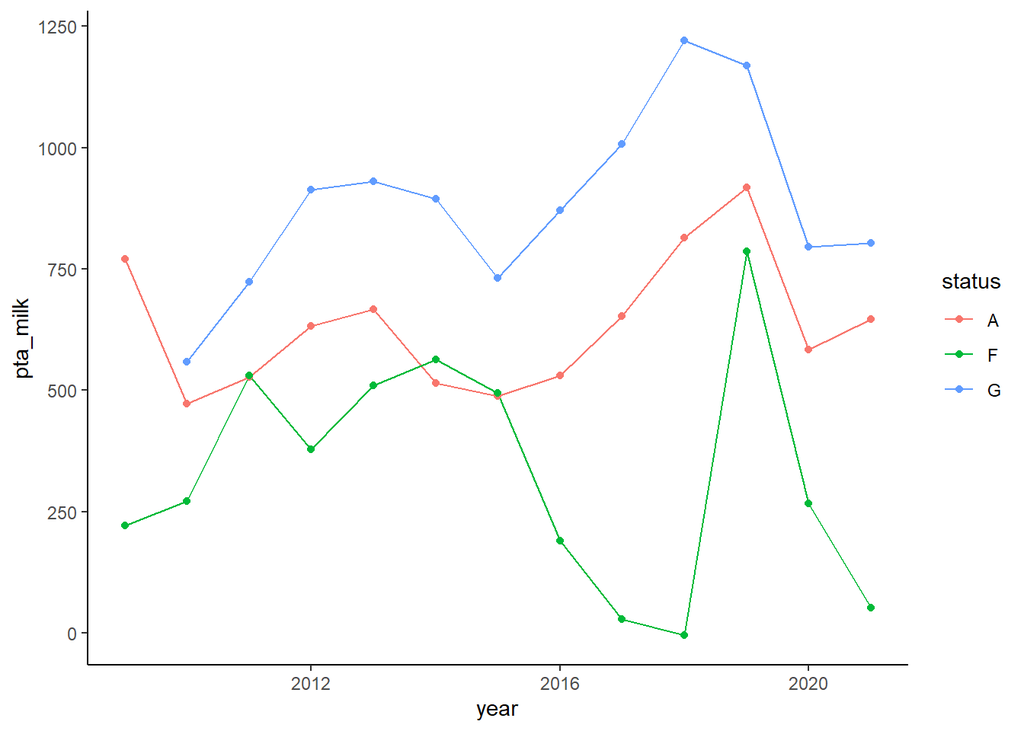

```r
naab_aiss |>
  group_by(reg_id) |>
  arrange(year_proof) |>
  slice_tail(n = 1) |>
  ungroup() |>
  filter(!is.na(status) & year > 2008) |>
  group_by(year, status) |>
  summarise(pta_milk = mean(pta_milk, na.rm = TRUE)) |>
  #pivot_wider(id_cols = year, names_from = "status", values_from = "NM") |>
  ggplot(aes(x = year, y = pta_milk, group = status)) +
  geom_line(aes(color = status)) +
  geom_point(aes(color = status)) +
  theme_classic()
```

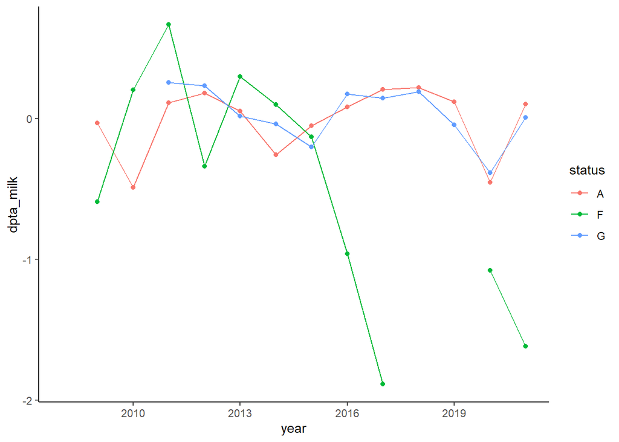

```r
naab_aiss |>
  group_by(reg_id) |>
  arrange(year_proof) |>
  slice_tail(n = 1) |>
  ungroup() |>
  filter(!is.na(status) & year > 2007) |>
  group_by(year, status) |>
  summarise(pta_milk = mean(pta_milk, na.rm = TRUE)) |>
  ungroup() |>
  pivot_wider(id_cols = year, names_from = "status", values_from = "pta_milk") |>
  mutate(A_1 = dplyr::lag(A, n = 1),
         F_1 = dplyr::lag(F, n = 1),
         G_1 = dplyr::lag(G, n = 1),
         dA = log(A)-log(A_1),
         dF = log(F)-log(F_1),
         dG = log(G)-log(G_1)) |>
  select(c(year, dA, dG, dF)) |>
  rename(A = dA, F = dF, G = dG) |>
  pivot_longer(cols = A:F, names_to = "status", values_to = "dpta_milk") |>
  ggplot(aes(x = year, y = dpta_milk, group = status)) +
  geom_line(aes(color = status)) +
  geom_point(aes(color = status)) +
  theme_classic()
```

Changes in Inbreeding by type of proof and year of birth

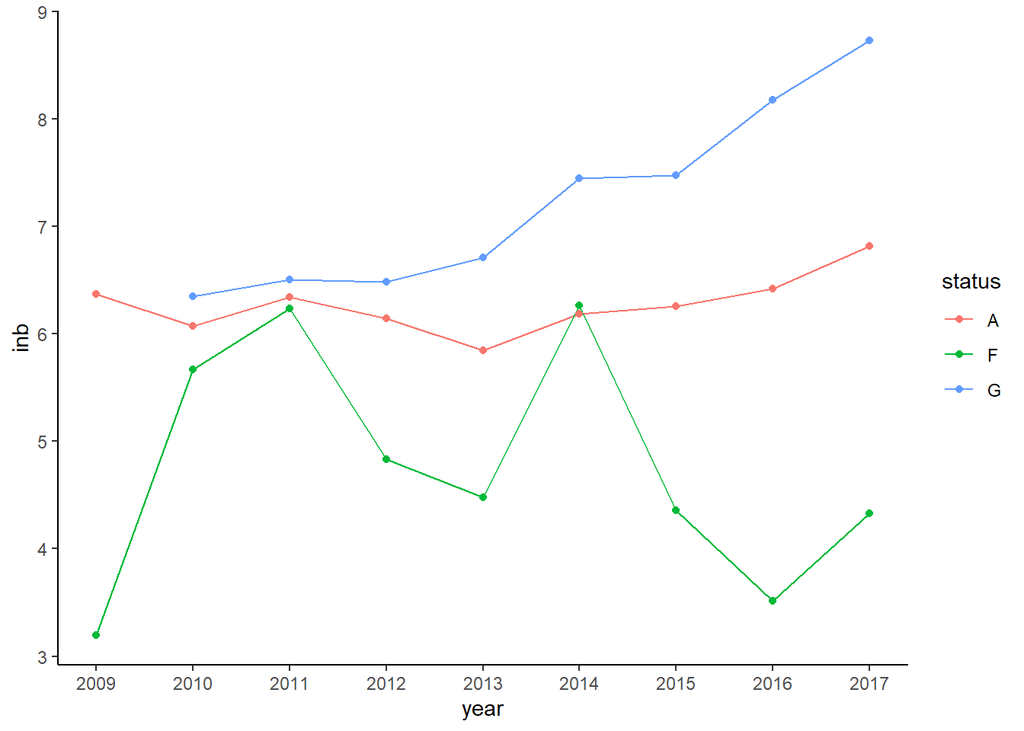

```r
naab_aiss |>
  group_by(reg_id) |>
  arrange(year_proof) |>
  slice_tail(n = 1) |>
  ungroup() |>
  filter(!is.na(status) & year > 2008 & year < 2018) |>
  group_by(year, status) |>
  summarise(inb = mean(inbreeding, ma.rm = TRUE)) |>
  #pivot_wider(id_cols = year, names_from = "status", values_from = "NM") |>
  ggplot(aes(x = year, y = inb, group = status)) +
  geom_line(aes(color = status)) +
  geom_point(aes(color = status)) +
  theme_classic() +
  scale_x_continuous(limits = c(2009, 2017), breaks = seq(2009, 2017, 1))
```

```r
naab_old <- read_csv("../../data/old_evals_clean.csv")
```

Number of sons per sire

```r
naab_old |>
  filter(!is.na(sire_name)) |>
  group_by(sire_name, status) |>
  summarise(num_sons = n()) |>
  arrange(desc(num_sons))
```

| sire_name | status | num_sons |
| --- | --- | --- |
| PICSTON SHOTTLE-ET | I | 632 |
| BRAEDALE GOLDWYN | I | 428 |
| ENSENADA TABOO PLANET-ET | I | 405 |
| O-BEE MANFRED JUSTICE-ET | I | 377 |
| STOUDER MORTY-ET | I | 331 |
| RAMOS | I | 301 |
| END-ROAD PVF BOLIVER-ET | I | 293 |
| REGANCREST-HHF MAC-ET | I | 288 |
| LONG-LANGS OMAN OMAN-ET | I | 286 |
| MARA-THON BW MARSHALL-ET | I | 282 |

[output cut: 5749 more lines]

Number of sons per mgs

```r
naab_old |>
  filter(!is.na(mgs_name)) |>
  group_by(mgs_name) |>
  summarise(num_sons = n()) |>
  arrange(desc(num_sons))
```

| mgs_name | num_sons |
| --- | --- |
| PICSTON SHOTTLE-ET | 1673 |
| O-BEE MANFRED JUSTICE-ET | 979 |
| STARTMORE RUDOLPH-ET | 852 |
| REGANCREST ELTON DURHAM-ET | 805 |
| BRAEDALE GOLDWYN | 803 |
| MARA-THON BW MARSHALL-ET | 706 |
| ENSENADA TABOO PLANET-ET | 556 |
| COMESTAR OUTSIDE-ET | 531 |
| SEAGULL-BAY SUPERSIRE-ET | 474 |
| MAIZEFIELD BELLWOOD-ET | 397 |

[output cut: 3900 more lines]

Number of sires of genomic-tested bulls

```r
naab_old |>
  filter(status == "G") |>
  group_by(sire_name) |>
  summarise(num_sons = n())  |>
  arrange(desc(num_sons))
```

| sire_name | num_sons |
| --- | --- |
| WOODCREST KING DOC | 6 |
| ABS CRIMSON-ET | 3 |
| OUR-FAVORITE UNDENIED-ET | 3 |
| PROGENESIS POSITIVE | 3 |
| BOMAZ SKYWALKER-ET | 2 |
| BUTZ-HILL MEGASIRE-ET | 2 |
| DG CHARLEY | 2 |
| ENDCO THE ANSWER-PO-ET | 2 |
| LA RAINBOW BFLY DYNAMITE ETV | 2 |
| MR SALVATORE RC-ET | 2 |

[output cut: 60 more lines]

```r
naab |>
  filter(status == "G") |>
  group_by(sire_id) |>
  summarise(num_sons = n()) |>
  arrange(desc(num_sons))
```

| sire_id | num_sons |
| --- | --- |
| HO840003128557482 | 69 |
| HOUSA000074261651 | 59 |
| HO840003013654627 | 25 |
| HODEU000538920253 | 24 |
| HOCAN000012264620 | 23 |
| HO840003132349851 | 22 |
| HO840003137878481 | 21 |
| HO840003123886035 | 20 |
| HO840003132198276 | 18 |
| HO840003129037884 | 16 |

[output cut: 360 more lines]

Number of daughters distribution

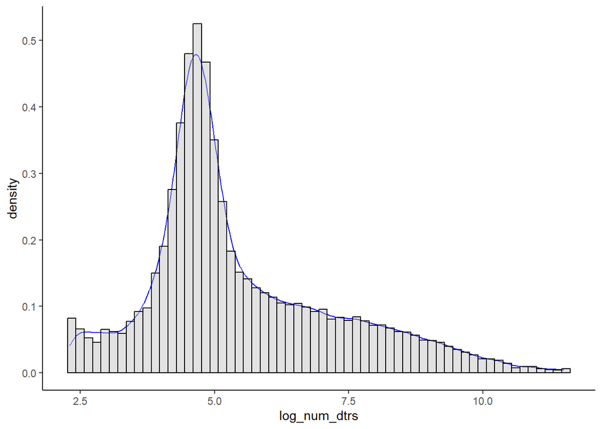

```r
naab_old |>
  filter(num_dtrs > 0) |>
  mutate(log_num_dtrs = log(num_dtrs)) |>
  ggplot(aes(x = log_num_dtrs)) +
  geom_density(color = "blue") +
  geom_histogram(aes(y = ..density..), bins = 60, fill = "grey", alpha = 0.45, color = "black") +
  theme_classic()
```

## Characterizing early adopters

# Farm names

```r
farm_names <- read_csv(paste0(folder, "/Box/WDE Results/bull_and_farm_names.csv"))
farm_names |>
  distinct(reg_id, .keep_all = TRUE) ->
  farm_names

naab_aiss <- left_join(naab_aiss, farm_names, by = join_by(reg_id == reg_id))
naab_aiss |>
  select(-naab_code.y) |>
  rename(naab_code = naab_code.x) ->
  naab_aiss
rm(cdn)
```

Inbreeding coefficient of early adopters

```r
eadopt <- naab_aiss |>
  filter(status == "G" & yob < 2010) |>
  group_by(reg_id) |>
  arrange(period) |>
  slice_head(n = 1) |>
  ungroup()

eadopt |>
  group_by(yob) |>
  summarise(mean = mean(inbreeding, na.rm = TRUE),
            max = max(inbreeding, na.rm = TRUE),
            min = min(inbreeding, na.rm = TRUE),
            N = n())
```

| yob | mean | max | min | N |
| --- | --- | --- | --- | --- |
| 2004 | 6.920000 | 7.88 | 5.96 | 2 |
| 2005 | 6.924444 | 15.69 | 1.84 | 27 |
| 2006 | 6.254021 | 18.13 | 0.57 | 97 |
| 2007 | 6.405699 | 17.85 | 0.00 | 193 |
| 2008 | 6.446329 | 13.04 | 0.00 | 395 |
| 2009 | 6.689054 | 16.46 | 0.00 | 571 |

```r
naab_aiss |>
  group_by(reg_id) |>
  arrange(period) |>
  slice_head(n = 1) |>
  ungroup() |>
  filter(yob > 2005 & !is.na(status)) |>
  group_by(yob, status) |>
  summarise(farm_name = n_distinct(farm_name, na.rm = TRUE)) |>
  pivot_wider(id_cols = yob, names_from = "status", values_from = "farm_name")
```

```
## argument.
```

| yob | A | F | G |
| --- | --- | --- | --- |
| 2006 | 107 | 35 | 48 |
| 2007 | 62 | 18 | 83 |
| 2008 | 50 | 21 | 155 |
| 2009 | 53 | 18 | 180 |
| 2010 | 41 | 13 | 263 |
| 2011 | 30 | 13 | 220 |
| 2012 | 15 | 12 | 273 |
| 2013 | 17 | 9 | 271 |
| 2014 | 18 | 6 | 242 |
| 2015 | 17 | 8 | 257 |

[output cut: 5 more lines]

# Marketing/stud codes

```r
companies <- read_csv("../../data/company_info.csv")
naab_aiss |>
  group_by(reg_id) |>
  arrange(period) |>
  slice_head(n = 1) |>
  ungroup() |>
  filter(yob > 2005 & !is.na(status)) |>
  group_by(yob, status) |>
  summarise(n_studs = n_distinct(primary_stud_code, na.rm = TRUE)) |>
  pivot_wider(id_cols = yob, names_from = "status", values_from = "n_studs") ->
  nstuds
```

```
## argument.
```

```r
kable(nstuds)
```

| yob | A | F | G |
| --- | --- | --- | --- |
| 2006 | 23 | 28 | 19 |
| 2007 | 17 | 17 | 21 |
| 2008 | 16 | 21 | 31 |
| 2009 | 15 | 13 | 35 |
| 2010 | 10 | 12 | 40 |
| 2011 | 11 | 8 | 42 |
| 2012 | 7 | 11 | 46 |
| 2013 | 9 | 10 | 52 |
| 2014 | 7 | 8 | 58 |
| 2015 | 6 | 7 | 63 |
| 2016 | 4 | 1 | 68 |
| 2017 | 1 | NA | 73 |
| 2018 | NA | NA | 65 |
| 2019 | NA | NA | 58 |
| 2020 | NA | NA | 48 |

```r
companies |>
  mutate(date_1 = str_split(assigned, " ", simplify = TRUE)[,2],
         date_2 = str_split(assigned, " ", simplify = TRUE)[,5]) |>
  separate(date_1, into = c("assigned_date", "temp"), sep = ";") |>
  select(-temp) |>
  separate(date_2, into = c("end_date", "temp"), sep = ";") |>
  select(-temp) |>
  mutate(assigned_date = mdy(assigned_date),
         end_date = mdy(end_date)) |>
  select(-assigned) ->
  companies
```

```r
companies |>
 arrange(assigned_date) |>
  select(-c(notes, parent_company)) |>
  mutate(reg_year = year(assigned_date)) |>
  group_by(reg_year) |>
  summarise(N = n())
```

| reg_year | N |
| --- | --- |
| 1965 | 1 |
| 1967 | 1 |
| 1968 | 1 |
| 1969 | 3 |
| 1970 | 5 |
| 1971 | 4 |
| 1972 | 4 |
| 1973 | 2 |
| 1974 | 40 |
| 1975 | 6 |

[output cut: 49 more lines]

```r
naab_aiss <- left_join(naab_aiss, companies, by = "primary_stud_code")
```

```r
naab_aiss |>
  mutate(reg_year = year(assigned_date)) |>
  group_by(reg_id) |>
  arrange(year_proof) |>
  slice_head(n = 1) |>
  ungroup() |>
  filter(year_proof %in% 2009:2012 & !is.na(status)) |>
  group_by(status, reg_year) |>
  summarise(N = n()) |>
  pivot_wider(id_cols = reg_year, names_from = "status", values_from = "N") |>
  arrange(reg_year)
```

| reg_year | A | F | G |
| --- | --- | --- | --- |
| 1970 | 187 | 15 | 96 |
| 1972 | 108 | 23 | 296 |
| 1973 | 165 | 5 | 345 |
| 1974 | 68 | 6 | 181 |
| 1975 | 8 | NA | 12 |
| 1977 | 3 | NA | 8 |
| 1983 | 2 | NA | NA |
| 1985 | 8 | NA | 10 |
| 1987 | 9 | NA | 100 |
| 1988 | 7 | 4 | 128 |

[output cut: 19 more lines]

```r
naab_aiss |>
  mutate(parent_company = ifelse(is.na(parent_company), company_name, parent_company)) |>
  group_by(reg_id) |>
  arrange(year_proof) |>
  slice_head(n = 1) |>
  ungroup() |>
  filter(year_proof > 2009 & year_proof < 2014 & !is.na(status)) |>
  tab(year_proof, parent_company, status) |>
  select(c(year_proof, parent_company, status, Freq.)) |>
  pivot_wider(id_cols = c(year_proof, parent_company), names_from = "status", values_from = "Freq.") |>
  data.frame()
```

```
##
## year_p~f │ parent~y │ status │    Freq.  Percent     Cum.
## ─────────┼──────────┼────────┼────────────────────────────
##     2010 │ A.I. T~. │      G │        3     0.06     0.06
##     2010 │ AA Bre~s │      A │        1     0.02     0.09
##     2010 │ ABS Gl~l │      A │       66     1.41     1.49
##     2010 │ ABS Gl~l │      F │        3     0.06     1.56
##     2010 │ ABS Gl~l │      G │       36     0.77     2.32
##     2010 │ Alta G~s │      A │       35     0.75     3.07
##     2010 │ Alta G~s │      F │       13     0.28     3.35
##     2010 │ Alta G~s │      G │      100     2.13     5.48
##     2010 │ Alta G~n │      F │        1     0.02     5.50
##     2010 │ Androg~s │      A │        3     0.06     5.56
##     2010 │ Androg~s │      G │       46     0.98     6.54
##     2010 │ CRV Ho~g │      F │       32     0.68     7.22
```

[output cut: 231 more lines]

| year_proof | parent_company | G | A | F |
| --- | --- | --- | --- | --- |
| 2010 | A.I. Total B.V. | 3 | NA | NA |
| 2010 | AA Breeders | NA | 1 | NA |
| 2010 | ABS Global | 36 | 66 | 3 |
| 2010 | Alta Genetics | 100 | 35 | 13 |
| 2010 | Alta Genetics, Canadian AI Division | NA | NA | 1 |
| 2010 | Androgenics | 46 | 3 | NA |
| 2010 | CRV Holding | 4 | NA | 32 |
| 2010 | Central Valley Dairy Breeders | 2 | 4 | NA |
| 2010 | Dependa-Bull Genetics | NA | 2 | NA |
| 2010 | El Toro Genetics-Bill Hillier | 17 | 6 | NA |

[output cut: 138 more lines]

```r
naab_aiss |>
  mutate(parent_company = ifelse(is.na(parent_company), company_name, parent_company)) |>
  group_by(reg_id) |>
  arrange(year_proof) |>
  slice_head(n = 1) |>
  ungroup() |>
  group_by(parent_company) |>
  summarise(min = min(year_proof)) |>
  arrange(min)
```

| parent_company | min |
| --- | --- |
| AA Breeders | 2000 |
| ABS Global | 2000 |
| Alpenseme-Federazione Prov. Le Allevatori-Trento | 2000 |
| Alta Genetics | 2000 |
| Alta Genetics, Canadian AI Division | 2000 |
| Ambreez, NZ, Ltd. | 2000 |
| Androgenics | 2000 |
| CRV Holding | 2000 |
| Central Valley Dairy Breeders | 2000 |
| Cogent Breeding Ltd. | 2000 |

[output cut: 119 more lines]

Large vs. small firms: supports the intensive-margin hypothesis, large firms adopted G earlier and to a larger extent

```
##
## company_size │ company_date │     year │    Freq.  Percent     Cum.
## ─────────────┼──────────────┼──────────┼────────────────────────────
##        Large │     existing │     2000 │      814     3.89     3.89
##        Large │     existing │     2001 │      155     0.74     4.63
##        Large │     existing │     2002 │      322     1.54     6.17
##        Large │     existing │     2003 │      209     1.00     7.17
##        Large │     existing │     2004 │      222     1.06     8.23
##        Large │     existing │     2005 │      226     1.08     9.31
##        Large │     existing │     2006 │      281     1.34    10.66
##        Large │     existing │     2007 │      210     1.00    11.66
##        Large │     existing │     2008 │      301     1.44    13.10
##        Large │     existing │     2009 │      282     1.35    14.45
##        Large │     existing │     2010 │     1186     5.67    20.12
##        Large │     existing │     2011 │      928     4.44    24.55
##        Large │     existing │     2012 │      809     3.87    28.42
##        Large │     existing │     2013 │     1039     4.97    33.39
##        Large │     existing │     2014 │     1057     5.05    38.44
##        Large │     existing │     2015 │     1012     4.84    43.28
##        Large │     existing │     2016 │     1234     5.90    49.18
##        Large │     existing │     2017 │      962     4.60    53.78
##        Large │     existing │     2018 │     1190     5.69    59.47
##        Large │     existing │     2019 │     1075     5.14    64.60
##        Large │     existing │     2020 │     1135     5.43    70.03
##        Large │     existing │     2021 │      814     3.89    73.92
## -------------┼--------------┼----------┼----------------------------
##        Small │     existing │     2000 │      325     1.55    75.48
##        Small │     existing │     2001 │       80     0.38    75.86
##        Small │     existing │     2002 │       84     0.40    76.26
##        Small │     existing │     2003 │       72     0.34    76.60
##        Small │     existing │     2004 │       58     0.28    76.88
##        Small │     existing │     2005 │       59     0.28    77.16
##        Small │     existing │     2006 │       59     0.28    77.45
##        Small │     existing │     2007 │       34     0.16    77.61
##        Small │     existing │     2008 │       72     0.34    77.95
##        Small │     existing │     2009 │       63     0.30    78.25
##        Small │     existing │     2010 │      183     0.87    79.13
##        Small │     existing │     2011 │      126     0.60    79.73
##        Small │     existing │     2012 │      150     0.72    80.45
##        Small │     existing │     2013 │      129     0.62    81.06
```

[output cut: 15 more lines]

```
##        Small │          new │     2007 │        3     0.01    89.43
##        Small │          new │     2008 │        8     0.04    89.47
##        Small │          new │     2009 │        6     0.03    89.50
##        Small │          new │     2010 │       41     0.20    89.70
##        Small │          new │     2011 │       60     0.29    89.98
##        Small │          new │     2012 │      107     0.51    90.50
##        Small │          new │     2013 │       84     0.40    90.90
##        Small │          new │     2014 │      138     0.66    91.56
##        Small │          new │     2015 │      155     0.74    92.30
##        Small │          new │     2016 │      193     0.92    93.22
##        Small │          new │     2017 │      203     0.97    94.19
##        Small │          new │     2018 │      384     1.84    96.03
##        Small │          new │     2019 │      280     1.34    97.37
##        Small │          new │     2020 │      330     1.58    98.94
##        Small │          new │     2021 │      221     1.06   100.00
```

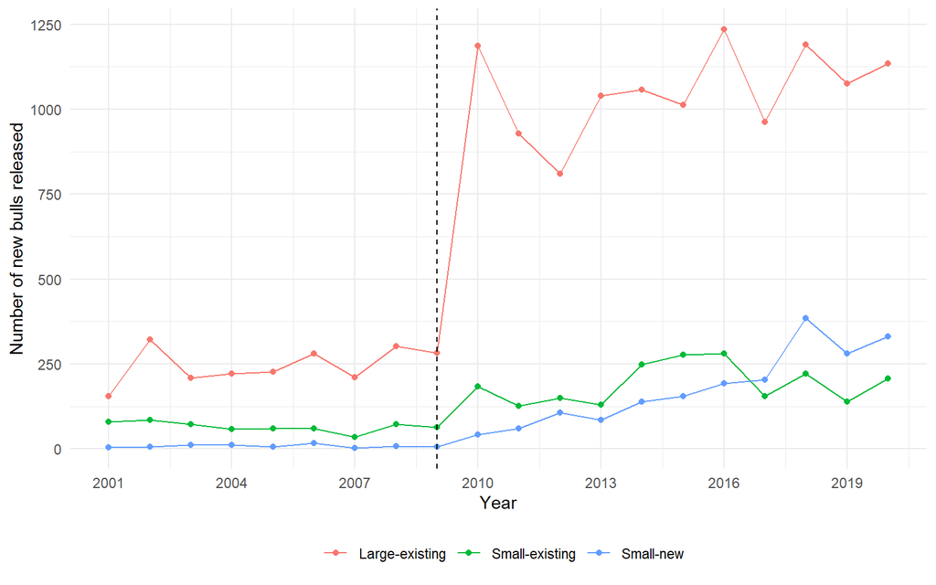

```r
naab_aiss |>
  mutate(parent_company = ifelse(is.na(parent_company), company_name, parent_company),
         company_size = ifelse(parent_company %in% c("Select Sires", "Semex Alliance", "ABS Global", "STgenetics",
                                                     "Alta Genetics", "Genex", "CRV Holding"), "Large", "Small"),
         company_date = ifelse(parent_company %in%  c("AA Breeders", "ABS Global",
                                                      "Alpenseme-Federazione Prov. Le Allevatori-Trento",
                                 "Alta Genetics", "Ambreez, NZ, Ltd.", "Androgenics", "CRV Holding",
                                 "Central Valley Dairy Breeders", "Cogent Breeding Ltd.",
                                 "Cooperative Agricole D'Insemination Artificielle de Crehen UNECO", "EastGen Inc.",
                                 "Excelsior Farms", "Galaxie Genetics Reproductive Center, Inc.", "Genes Diffusion",
                                 "Genex", "Golden State Breeders", "Hawkeye Breeders", "Hoffman A.I. Breeders",
                                 "Inseme SPA", "Interglobe Genetics", "JLG Enterprises", "KI Samen b.v.",
                                 "Livestock Improvement Corporation Ltd.", "Masterrind GmbH",
                                 "North American Breeders, Inc.", "Rocky Mountain Sire Services, Inc.", "STgenetics",
                                 "Select Sires", "Semex Alliance", "Southeastern Semen Services, Inc.", "Synetics",
                                 "Triple Crown Sires", "Universal Genetics Ltd.", "Urus", "WESTGEN",
                                 "Zimmerman's Custom Freezing", "['INTERMIZOO S.p.a.' 'INTERMIZOO S.p.A.']",
                                 "Centro Provinciale per la Fecondazione Artificiale", "Dependa-Bull Genetics",
                                 "Genetic Connection", "Inseme, SPA", "VOST (Verein Ostfriesischer Stammviehzuchter e.G.",
                                 "Belmont Breeders", "RBB (Rinderproduktion Berlin-Brandenburg GmbH)",
                                 "RPN (Rinderproduktion Niedersachsen Gmbh)", "RSA (Rinderzuchtverband Sachsen-Anhalt eG)",
                                 "RSH (Rinderzucht Schleswig-Holstein eG)", "RUW (Rinder-Union West e.G.)",
                                 "WEU (Weser-EMS-Union eG)", "C.O.F.A. (Cooperativa di Fecondazione Artificiale)",
                                 "Nederlandse Vereniging voor KI Kampen","Viking Genetics",
                                 "Union Regionale des Cooperaties d'Elevage de I'Ouest (URECO)", "Cogent Canada Corp.",
                                 "Swissgenetics/AI Center Muelligen", "CBS - Czech Breeding Services s.r.o.",
                                 "Central Wisconsin Semen Freezing Service", "Rinderbesamungs-Genossenschaft Memmingen",
                                 "Shore Genetics, Inc.", "El Toro Genetics-Bill Hillier", "Global Ag Alliance, Inc.",
                                 "Natural SPOL-SRO", "Robert Bignami-Brentwood Farms",
                                 "Southern Idaho Reproductive Enterprises (S.I.R.E)", "CIA Alsace Genetique/UNECO",
                                 "CIA Mayenne UNECO", "Centro Tori Chiacchierini Di Chiacchierini Anna",
                                 "Flatness International, Inc.", "MIDA TEST", "Origenplus", "Xenetica Fontao S.A."), "existing", "new")) |>
  group_by(reg_id) |>
  arrange(year_proof) |>
  slice_head(n = 1) |>
  ungroup() |>
  tab(company_size, company_date, year) |>
  filter(year > 2000 & year <= 2020) |>
  mutate(group = paste0(company_size, "-", company_date)) |>
  ggplot(aes(x = year, y = Freq., group = group)) +
  geom_line(aes(color = group)) +
  geom_point(aes(color = group)) +
  theme_minimal() +
  theme(legend.title = element_blank(),
        legend.position = "bottom") +
  geom_vline(xintercept =  2009, linetype = 2) +
  scale_x_continuous(breaks = seq(2001, 2019, 3)) +
  xlab("Year") +
  ylab("Number of new bulls released")
```

Active sires only: they do come from large-established firms!

```
##
## company_size │ company_date │     year │    Freq.  Percent     Cum.
## ─────────────┼──────────────┼──────────┼────────────────────────────
##        large │     existing │     2000 │      716    16.43    16.43
##        large │     existing │     2001 │      131     3.01    19.43
##        large │     existing │     2002 │      275     6.31    25.74
##        large │     existing │     2003 │      164     3.76    29.50
##        large │     existing │     2004 │      177     4.06    33.56
##        large │     existing │     2005 │      183     4.20    37.76
##        large │     existing │     2006 │      228     5.23    42.99
##        large │     existing │     2007 │      180     4.13    47.12
##        large │     existing │     2008 │      238     5.46    52.58
##        large │     existing │     2009 │      246     5.64    58.22
##        large │     existing │     2010 │      266     6.10    64.33
##        large │     existing │     2011 │      160     3.67    68.00
##        large │     existing │     2012 │      127     2.91    70.91
##        large │     existing │     2013 │      106     2.43    73.34
##        large │     existing │     2014 │       94     2.16    75.50
##        large │     existing │     2015 │       69     1.58    77.08
##        large │     existing │     2016 │       42     0.96    78.05
##        large │     existing │     2017 │       22     0.50    78.55
##        large │     existing │     2018 │       27     0.62    79.17
##        large │     existing │     2019 │       35     0.80    79.97
##        large │     existing │     2020 │       23     0.53    80.50
##        large │     existing │     2021 │        7     0.16    80.66
## -------------┼--------------┼----------┼----------------------------
##        small │     existing │     2000 │      257     5.90    86.56
##        small │     existing │     2001 │       55     1.26    87.82
##        small │     existing │     2002 │       57     1.31    89.13
##        small │     existing │     2003 │       51     1.17    90.30
##        small │     existing │     2004 │       43     0.99    91.28
##        small │     existing │     2005 │       48     1.10    92.38
##        small │     existing │     2006 │       37     0.85    93.23
##        small │     existing │     2007 │       26     0.60    93.83
##        small │     existing │     2008 │       42     0.96    94.79
##        small │     existing │     2009 │       39     0.89    95.69
##        small │     existing │     2010 │       37     0.85    96.54
##        small │     existing │     2011 │       21     0.48    97.02
##        small │     existing │     2012 │       10     0.23    97.25
##        small │     existing │     2013 │        9     0.21    97.45
```

[output cut: 13 more lines]

```
##        small │          new │     2005 │        3     0.07    98.76
##        small │          new │     2006 │        4     0.09    98.85
##        small │          new │     2007 │        1     0.02    98.88
##        small │          new │     2009 │        3     0.07    98.94
##        small │          new │     2010 │        4     0.09    99.04
##        small │          new │     2011 │        2     0.05    99.08
##        small │          new │     2012 │       11     0.25    99.33
##        small │          new │     2013 │        7     0.16    99.50
##        small │          new │     2014 │        3     0.07    99.56
##        small │          new │     2015 │        4     0.09    99.66
##        small │          new │     2017 │        2     0.05    99.70
##        small │          new │     2018 │        1     0.02    99.72
##        small │          new │     2019 │        2     0.05    99.77
##        small │          new │     2020 │        8     0.18    99.95
##        small │          new │     2021 │        2     0.05   100.00
```

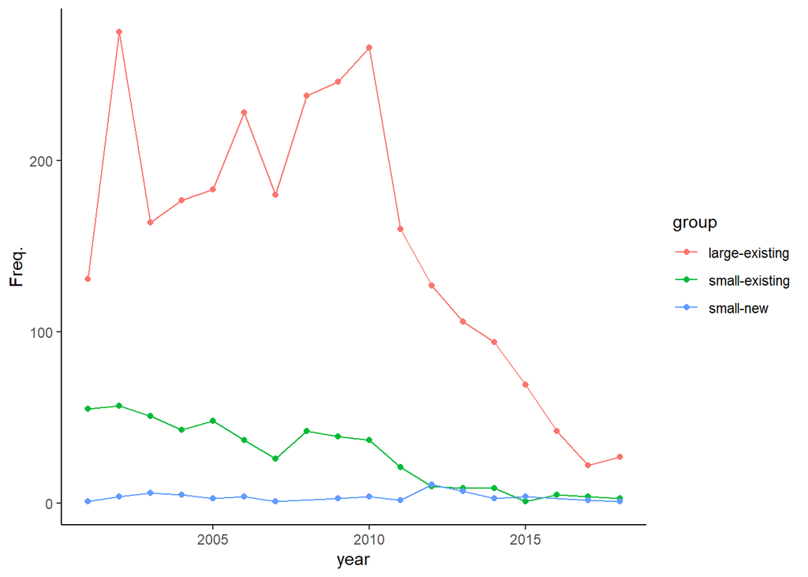

```r
naab_aiss |>
  mutate(parent_company = ifelse(is.na(parent_company), company_name, parent_company),
         company_size = ifelse(parent_company %in% c("Select Sires", "Semex Alliance", "ABS Global", "STgenetics",
                                                     "Alta Genetics", "Genex", "CRV Holding"), "large", "small"),
         company_date = ifelse(parent_company %in%  c("AA Breeders", "ABS Global",
                                                      "Alpenseme-Federazione Prov. Le Allevatori-Trento",
                                 "Alta Genetics", "Ambreez, NZ, Ltd.", "Androgenics", "CRV Holding",
                                 "Central Valley Dairy Breeders", "Cogent Breeding Ltd.",
                                 "Cooperative Agricole D'Insemination Artificielle de Crehen UNECO", "EastGen Inc.",
                                 "Excelsior Farms", "Galaxie Genetics Reproductive Center, Inc.", "Genes Diffusion",
                                 "Genex", "Golden State Breeders", "Hawkeye Breeders", "Hoffman A.I. Breeders",
                                 "Inseme SPA", "Interglobe Genetics", "JLG Enterprises", "KI Samen b.v.",
                                 "Livestock Improvement Corporation Ltd.", "Masterrind GmbH",
                                 "North American Breeders, Inc.", "Rocky Mountain Sire Services, Inc.", "STgenetics",
                                 "Select Sires", "Semex Alliance", "Southeastern Semen Services, Inc.", "Synetics",
                                 "Triple Crown Sires", "Universal Genetics Ltd.", "Urus", "WESTGEN",
                                 "Zimmerman's Custom Freezing", "['INTERMIZOO S.p.a.' 'INTERMIZOO S.p.A.']",
                                 "Centro Provinciale per la Fecondazione Artificiale", "Dependa-Bull Genetics",
                                 "Genetic Connection", "Inseme, SPA", "VOST (Verein Ostfriesischer Stammviehzuchter e.G.",
                                 "Belmont Breeders", "RBB (Rinderproduktion Berlin-Brandenburg GmbH)",
                                 "RPN (Rinderproduktion Niedersachsen Gmbh)", "RSA (Rinderzuchtverband Sachsen-Anhalt eG)",
                                 "RSH (Rinderzucht Schleswig-Holstein eG)", "RUW (Rinder-Union West e.G.)",
                                 "WEU (Weser-EMS-Union eG)", "C.O.F.A. (Cooperativa di Fecondazione Artificiale)",
                                 "Nederlandse Vereniging voor KI Kampen","Viking Genetics",
                                 "Union Regionale des Cooperaties d'Elevage de I'Ouest (URECO)", "Cogent Canada Corp.",
                                 "Swissgenetics/AI Center Muelligen", "CBS - Czech Breeding Services s.r.o.",
                                 "Central Wisconsin Semen Freezing Service", "Rinderbesamungs-Genossenschaft Memmingen",
                                 "Shore Genetics, Inc.", "El Toro Genetics-Bill Hillier", "Global Ag Alliance, Inc.",
                                 "Natural SPOL-SRO", "Robert Bignami-Brentwood Farms",
                                 "Southern Idaho Reproductive Enterprises (S.I.R.E)", "CIA Alsace Genetique/UNECO",
                                 "CIA Mayenne UNECO", "Centro Tori Chiacchierini Di Chiacchierini Anna",
                                 "Flatness International, Inc.", "MIDA TEST", "Origenplus", "Xenetica Fontao S.A."), "existing", "new")) |>
  group_by(reg_id) |>
  arrange(year_proof) |>
  slice_head(n = 1) |>
  ungroup() |>
  filter(status == "A") |>
  tab(company_size, company_date, year) |>
  filter(year > 2000 & year < 2019) |>
  mutate(group = paste0(company_size, "-", company_date)) |>
  ggplot(aes(x = year, y = Freq., group = group)) +
  geom_line(aes(color = group)) +
  geom_point(aes(color = group)) +
  theme_classic()
```

Genomic sires only

```
##
## company_size │ company_date │     year │    Freq.  Percent     Cum.
## ─────────────┼──────────────┼──────────┼────────────────────────────
##        large │     existing │     2010 │      709     4.80     4.80
##        large │     existing │     2011 │      652     4.41     9.22
##        large │     existing │     2012 │      610     4.13    13.35
##        large │     existing │     2013 │      881     5.97    19.31
##        large │     existing │     2014 │      911     6.17    25.48
##        large │     existing │     2015 │      919     6.22    31.70
##        large │     existing │     2016 │     1160     7.85    39.56
##        large │     existing │     2017 │      918     6.22    45.77
##        large │     existing │     2018 │     1160     7.85    53.63
##        large │     existing │     2019 │     1034     7.00    60.63
##        large │     existing │     2020 │     1105     7.48    68.11
##        large │     existing │     2021 │      775     5.25    73.36
## -------------┼--------------┼----------┼----------------------------
##        small │     existing │     2010 │      129     0.87    74.23
##        small │     existing │     2011 │       82     0.56    74.79
##        small │     existing │     2012 │      113     0.77    75.55
##        small │     existing │     2013 │       96     0.65    76.20
##        small │     existing │     2014 │      197     1.33    77.53
##        small │     existing │     2015 │      242     1.64    79.17
##        small │     existing │     2016 │      266     1.80    80.97
##        small │     existing │     2017 │      149     1.01    81.98
##        small │     existing │     2018 │      161     1.09    83.07
##        small │     existing │     2019 │      133     0.90    83.97
##        small │     existing │     2020 │      198     1.34    85.31
##        small │     existing │     2021 │      123     0.83    86.15
##        small │          new │     2010 │       22     0.15    86.30
##        small │          new │     2011 │       39     0.26    86.56
##        small │          new │     2012 │       87     0.59    87.15
##        small │          new │     2013 │       67     0.45    87.60
##        small │          new │     2014 │      126     0.85    88.46
##        small │          new │     2015 │      134     0.91    89.36
##        small │          new │     2016 │      185     1.25    90.62
##        small │          new │     2017 │      199     1.35    91.96
##        small │          new │     2018 │      382     2.59    94.55
##        small │          new │     2019 │      273     1.85    96.40
##        small │          new │     2020 │      314     2.13    98.52
##        small │          new │     2021 │      218     1.48   100.00
```

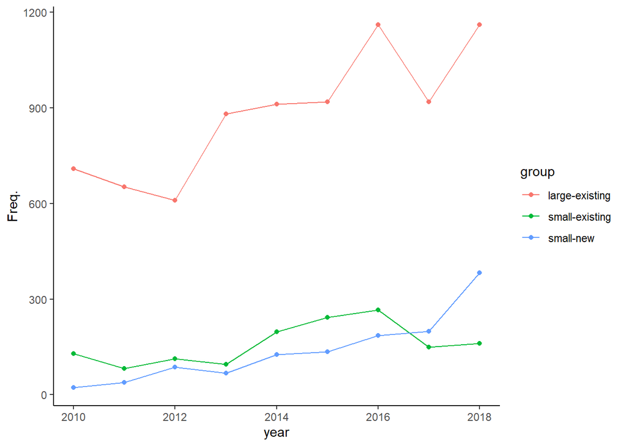

```r
naab_aiss |>
  mutate(parent_company = ifelse(is.na(parent_company), company_name, parent_company),
         company_size = ifelse(parent_company %in% c("Select Sires", "Semex Alliance", "ABS Global", "STgenetics",
                                                     "Alta Genetics", "Genex", "CRV Holding"), "large", "small"),
         company_date = ifelse(parent_company %in%  c("AA Breeders", "ABS Global",
                                                      "Alpenseme-Federazione Prov. Le Allevatori-Trento",
                                 "Alta Genetics", "Ambreez, NZ, Ltd.", "Androgenics", "CRV Holding",
                                 "Central Valley Dairy Breeders", "Cogent Breeding Ltd.",
                                 "Cooperative Agricole D'Insemination Artificielle de Crehen UNECO", "EastGen Inc.",
                                 "Excelsior Farms", "Galaxie Genetics Reproductive Center, Inc.", "Genes Diffusion",
                                 "Genex", "Golden State Breeders", "Hawkeye Breeders", "Hoffman A.I. Breeders",
                                 "Inseme SPA", "Interglobe Genetics", "JLG Enterprises", "KI Samen b.v.",
                                 "Livestock Improvement Corporation Ltd.", "Masterrind GmbH",
                                 "North American Breeders, Inc.", "Rocky Mountain Sire Services, Inc.", "STgenetics",
                                 "Select Sires", "Semex Alliance", "Southeastern Semen Services, Inc.", "Synetics",
                                 "Triple Crown Sires", "Universal Genetics Ltd.", "Urus", "WESTGEN",
                                 "Zimmerman's Custom Freezing", "['INTERMIZOO S.p.a.' 'INTERMIZOO S.p.A.']",
                                 "Centro Provinciale per la Fecondazione Artificiale", "Dependa-Bull Genetics",
                                 "Genetic Connection", "Inseme, SPA", "VOST (Verein Ostfriesischer Stammviehzuchter e.G.",
                                 "Belmont Breeders", "RBB (Rinderproduktion Berlin-Brandenburg GmbH)",
                                 "RPN (Rinderproduktion Niedersachsen Gmbh)", "RSA (Rinderzuchtverband Sachsen-Anhalt eG)",
                                 "RSH (Rinderzucht Schleswig-Holstein eG)", "RUW (Rinder-Union West e.G.)",
                                 "WEU (Weser-EMS-Union eG)", "C.O.F.A. (Cooperativa di Fecondazione Artificiale)",
                                 "Nederlandse Vereniging voor KI Kampen","Viking Genetics",
                                 "Union Regionale des Cooperaties d'Elevage de I'Ouest (URECO)", "Cogent Canada Corp.",
                                 "Swissgenetics/AI Center Muelligen", "CBS - Czech Breeding Services s.r.o.",
                                 "Central Wisconsin Semen Freezing Service", "Rinderbesamungs-Genossenschaft Memmingen",
                                 "Shore Genetics, Inc.", "El Toro Genetics-Bill Hillier", "Global Ag Alliance, Inc.",
                                 "Natural SPOL-SRO", "Robert Bignami-Brentwood Farms",
                                 "Southern Idaho Reproductive Enterprises (S.I.R.E)", "CIA Alsace Genetique/UNECO",
                                 "CIA Mayenne UNECO", "Centro Tori Chiacchierini Di Chiacchierini Anna",
                                 "Flatness International, Inc.", "MIDA TEST", "Origenplus", "Xenetica Fontao S.A."), "existing", "new")) |>
  group_by(reg_id) |>
  arrange(year_proof) |>
  slice_head(n = 1) |>
  ungroup() |>
  filter(status == "G") |>
  tab(company_size, company_date, year) |>
  filter(year > 2000 & year < 2019) |>
  mutate(group = paste0(company_size, "-", company_date)) |>
  ggplot(aes(x = year, y = Freq., group = group)) +
  geom_line(aes(color = group)) +
  geom_point(aes(color = group)) +
  theme_classic()
```

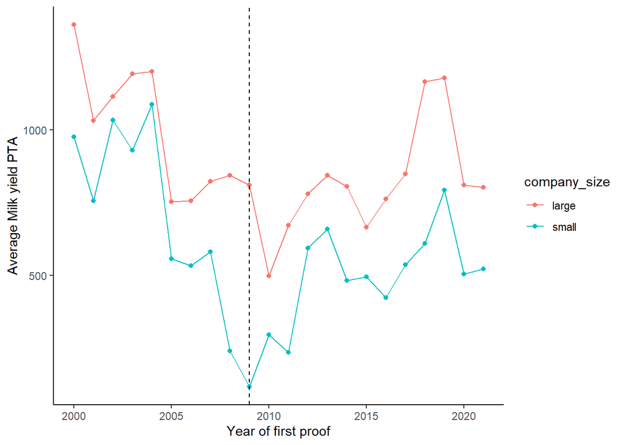

```r
naab_aiss |>
  mutate(parent_company = ifelse(is.na(parent_company), company_name, parent_company),
         company_size = ifelse(parent_company %in% c("Select Sires", "Semex Alliance", "ABS Global", "STgenetics",
                                                     "Alta Genetics", "Genex", "CRV Holding"), "large", "small"),
         company_date = ifelse(parent_company %in%  c("AA Breeders", "ABS Global",
                                                      "Alpenseme-Federazione Prov. Le Allevatori-Trento",
                                 "Alta Genetics", "Ambreez, NZ, Ltd.", "Androgenics", "CRV Holding",
                                 "Central Valley Dairy Breeders", "Cogent Breeding Ltd.",
                                 "Cooperative Agricole D'Insemination Artificielle de Crehen UNECO", "EastGen Inc.",
                                 "Excelsior Farms", "Galaxie Genetics Reproductive Center, Inc.", "Genes Diffusion",
                                 "Genex", "Golden State Breeders", "Hawkeye Breeders", "Hoffman A.I. Breeders",
                                 "Inseme SPA", "Interglobe Genetics", "JLG Enterprises", "KI Samen b.v.",
                                 "Livestock Improvement Corporation Ltd.", "Masterrind GmbH",
                                 "North American Breeders, Inc.", "Rocky Mountain Sire Services, Inc.", "STgenetics",
                                 "Select Sires", "Semex Alliance", "Southeastern Semen Services, Inc.", "Synetics",
                                 "Triple Crown Sires", "Universal Genetics Ltd.", "Urus", "WESTGEN",
                                 "Zimmerman's Custom Freezing", "['INTERMIZOO S.p.a.' 'INTERMIZOO S.p.A.']",
                                 "Centro Provinciale per la Fecondazione Artificiale", "Dependa-Bull Genetics",
                                 "Genetic Connection", "Inseme, SPA", "VOST (Verein Ostfriesischer Stammviehzuchter e.G.",
                                 "Belmont Breeders", "RBB (Rinderproduktion Berlin-Brandenburg GmbH)",
                                 "RPN (Rinderproduktion Niedersachsen Gmbh)", "RSA (Rinderzuchtverband Sachsen-Anhalt eG)",
                                 "RSH (Rinderzucht Schleswig-Holstein eG)", "RUW (Rinder-Union West e.G.)",
                                 "WEU (Weser-EMS-Union eG)", "C.O.F.A. (Cooperativa di Fecondazione Artificiale)",
                                 "Nederlandse Vereniging voor KI Kampen","Viking Genetics",
                                 "Union Regionale des Cooperaties d'Elevage de I'Ouest (URECO)", "Cogent Canada Corp.",
                                 "Swissgenetics/AI Center Muelligen", "CBS - Czech Breeding Services s.r.o.",
                                 "Central Wisconsin Semen Freezing Service", "Rinderbesamungs-Genossenschaft Memmingen",
                                 "Shore Genetics, Inc.", "El Toro Genetics-Bill Hillier", "Global Ag Alliance, Inc.",
                                 "Natural SPOL-SRO", "Robert Bignami-Brentwood Farms",
                                 "Southern Idaho Reproductive Enterprises (S.I.R.E)", "CIA Alsace Genetique/UNECO",
                                 "CIA Mayenne UNECO", "Centro Tori Chiacchierini Di Chiacchierini Anna",
                                 "Flatness International, Inc.", "MIDA TEST", "Origenplus", "Xenetica Fontao S.A."), "existing", "new")) |>
  group_by(reg_id) |>
  arrange(year_proof) |>
  slice_tail(n = 1) |>
  ungroup() |>
  #filter(year_proof < 2019) |>
  group_by(year_proof, company_size) |>
  summarise(pta_milk = mean(pta_milk, na.rm = TRUE)) |>
  ggplot(aes(x = year_proof, y = pta_milk)) +
  geom_point(aes(color = company_size)) +
  geom_line(aes(color = company_size)) +
  theme_classic() +
  geom_vline(xintercept =  2009, linetype = 2) +
  xlab("Year of first proof") +
  ylab("Average Milk yield PTA") +
  scale_x_continuous(breaks = seq(2000, 2020, 5))
```

Number of firms per year

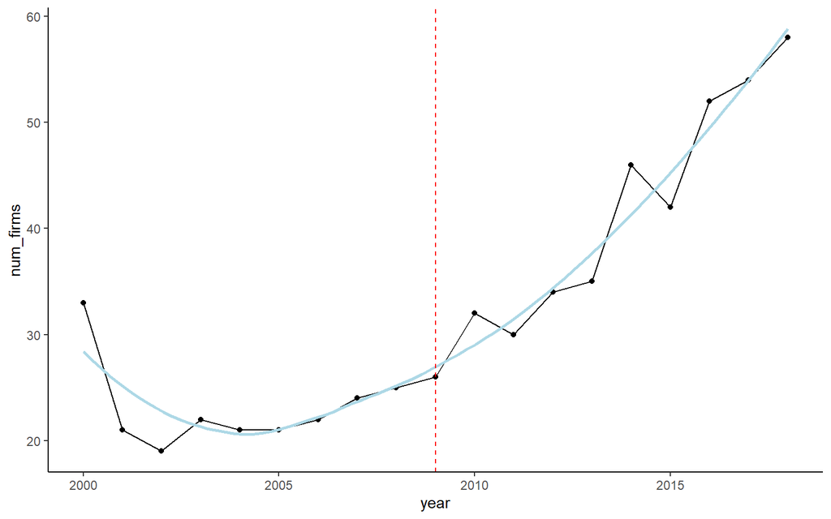

```r
naab_aiss |>
  filter(status %in% c("A", "G")) |>
  mutate(parent_company = ifelse(is.na(parent_company), company_name, parent_company))  |>
  group_by(reg_id) |>
  arrange(year_proof) |>
  slice_head(n = 1) |>
  ungroup() |>
  group_by(year, parent_company) |>
  slice_head(n = 1) |>
  ungroup() |>
  group_by(year) |>
  mutate(num_firms = 1:n()) |>
  slice_tail(n = 1) |>
  select(year, num_firms) |>
  filter(year < 2019) |>
  ggplot(aes(x = year, y = num_firms)) +
  geom_line() +
  geom_point() +
  geom_smooth(se = FALSE, color = "lightblue") +
  geom_vline(xintercept = 2009, color = "red", linetype = 2) +
  theme_classic()
```

Numbers of animals per firm and year explodes after GT is introduced!

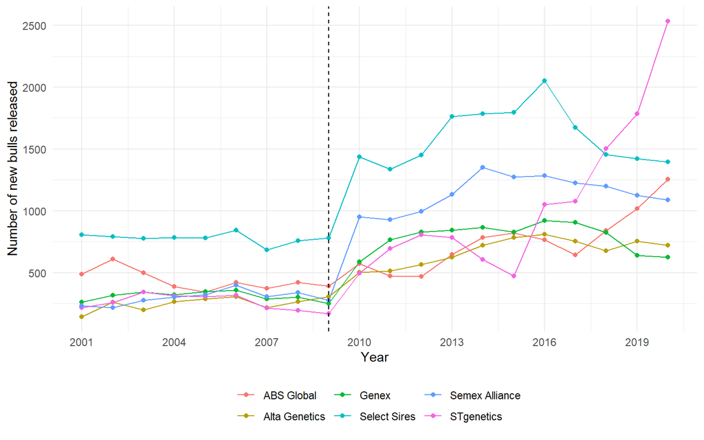

```r
naab_aiss |>
  mutate(parent_company = ifelse(is.na(parent_company), company_name, parent_company)) |>
  group_by(parent_company, year) |>
  mutate(num_bulls = 1:n()) |>
  slice_tail(n = 1) |>
  select(c(year, parent_company, num_bulls)) |>
  ungroup() |>
  filter(parent_company %in% c("ABS Global", "Genex", "Select Sires",
                               "Semex Alliance", "STgenetics", "Alta Genetics") &
           year > 2000 & year < 2021) |>
  ggplot(aes(x = year, y = num_bulls, group = parent_company)) +
  geom_line(aes(color = parent_company)) +
  geom_point(aes(color = parent_company)) +
  geom_vline(xintercept = 2009, color = "black", linetype = 2) +
  theme_minimal() +
  scale_x_continuous(breaks = seq(2001, 2019, 3)) +
  theme(legend.title = element_blank(),
        legend.position = "bottom") +
  xlab("Year") + ylab("Number of new bulls released")
```

But smaller firms do not increase the number of bulls so much

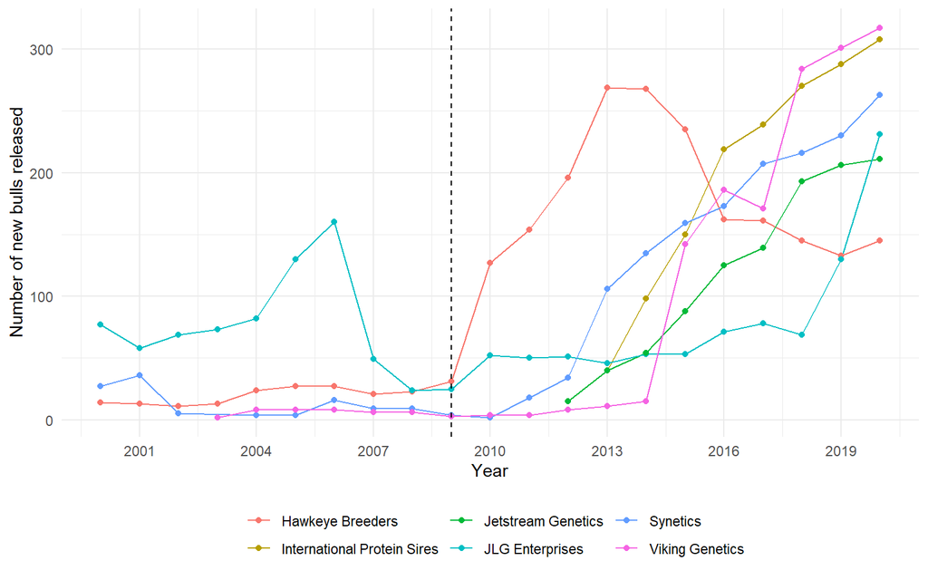

```r
naab_aiss |>
  mutate(parent_company = ifelse(is.na(parent_company), company_name, parent_company)) |>
  group_by(parent_company, year) |>
  mutate(num_bulls = 1:n()) |>
  slice_tail(n = 1) |>
  select(c(year, parent_company, num_bulls)) |>
  ungroup() |>
  filter(parent_company %in% c("Hawkeye Breeders", "International Protein Sires", "JLG Enterprises",
                               "Jetstream Genetics", "Synetics", "Viking Genetics") &
           year < 2021) |>
  ggplot(aes(x = year, y = num_bulls, group = parent_company)) +
  geom_line(aes(color = parent_company)) +
  geom_point(aes(color = parent_company)) +
  geom_vline(xintercept = 2009, color = "black", linetype = 2) +
  theme_minimal() +
  scale_x_continuous(breaks = seq(2001, 2019, 3)) +
  theme(legend.title = element_blank(),
        legend.position = "bottom") +
  xlab("Year") + ylab("Number of new bulls released")
```

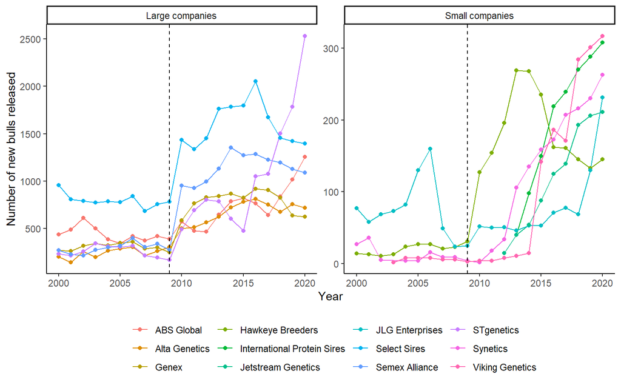

```r
naab_aiss |>
  mutate(parent_company = ifelse(is.na(parent_company), company_name, parent_company),
         size = case_when(
           parent_company %in% c("ABS Global", "Genex", "Select Sires",
                               "Semex Alliance", "STgenetics", "Alta Genetics") ~ "Large companies",
           parent_company %in% c("Hawkeye Breeders", "International Protein Sires", "JLG Enterprises",
                               "Jetstream Genetics", "Synetics", "Viking Genetics") ~ "Small companies")) |>
  filter(!is.na(size) & year < 2021) |>
  group_by(size, parent_company, year) |>
  mutate(num_bulls = 1:n()) |>
  slice_tail(n = 1) |>
  select(c(year, parent_company, num_bulls)) |>
  ungroup() |>
  ggplot(aes(x = year, y = num_bulls, group = parent_company)) +
  geom_line(aes(color = parent_company)) +
  geom_point(aes(color = parent_company)) +
  geom_vline(xintercept = 2009, color = "black", linetype = 2) +
  theme_classic() +
  theme(legend.title = element_blank(),
        legend.position = "bottom") +
  xlab("Year") + ylab("Number of new bulls released") +
  facet_wrap(.~size, scales = "free_y")
```

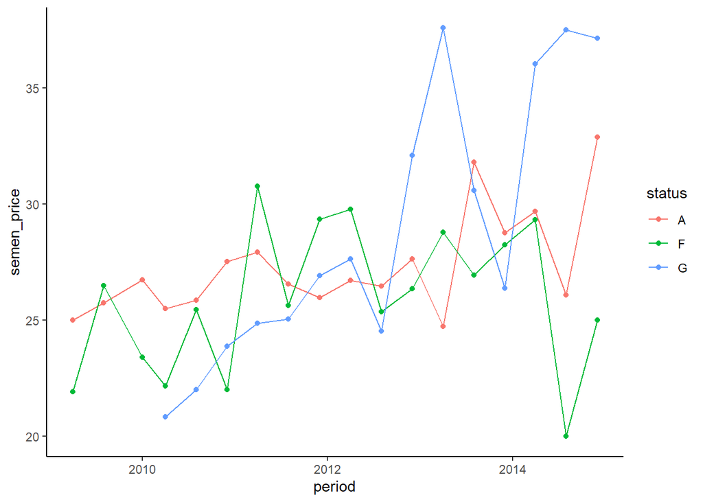

```r
naab_aiss |>
  group_by(reg_id) |>
  slice_max(order_by = semen_price, n = 1, na_rm = TRUE, with_ties = FALSE) |>
  ungroup() |>
  filter(!is.na(status)) |>
  group_by(period, status) |>
  summarise(semen_price = mean(semen_price, na.rm = TRUE)) |>
  filter(period > as.Date("2009-01-01") & period < as.Date("2015-01-01")) |>
  #pivot_wider(id_cols = period, names_from = "status", values_from = "semen_price") |>
  ggplot(aes(x = period, y = semen_price, group = status)) +
  geom_line(aes(color = status)) +
  geom_point(aes(color = status)) +
  theme_classic()
```

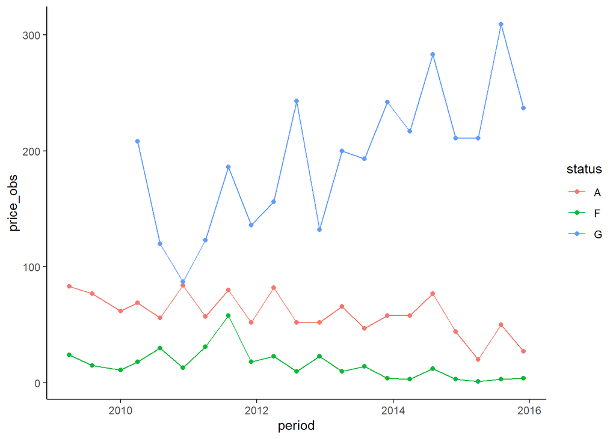

```r
naab_aiss |>
  group_by(reg_id) |>
  arrange(period) |>
  slice_max(order_by = semen_price, n = 1, na_rm = TRUE, with_ties = FALSE) |>
  ungroup() |>
  filter(!is.na(status)) |>
  group_by(period, status) |>
  summarise(price_obs = n()) |>
  filter(period > as.Date("2009-01-01") & period < as.Date("2016-01-01")) |>
  #pivot_wider(id_cols = period, names_from = "status", values_from = "semen_price") |>
  ggplot(aes(x = period, y = price_obs, group = status)) +
  geom_line(aes(color = status)) +
  geom_point(aes(color = status)) +
  theme_classic()
```

Bulls vs Sires PTAs

```r
naab_sires <- left_join(naab[, c("reg_id", "sire_id")],
                        naab_old[, c("reg_id", "status", "pta_fat_lb","pta_protein_lb", "pta_milk",
                                      "pta_scs", "pta_pl", "pta_dpr", "pta_hcr", "pta_ccr",
                                      "pta_liv", "pta_type", "pta_gest_length", "pta_heifer_liv",
                                      "pta_ketosis", "pta_efcalving", "pta_r_placenta",
                                      "pta_rear_legs_rear", "pta_foot_leg_score")],
                        by = join_by(sire_id == reg_id))

naab_sires |>
  filter(!is.na(status)) ->
  naab_sires
```

```r
naab_aiss |>
  group_by(reg_id) |>
  arrange(period) |>
  slice_tail(n = 1) |>
  ungroup() ->
naab_unique

naab_unique <- left_join(naab_unique,
                         naab_sires,
                          by = "reg_id")

naab_unique |>
  rename(status = status.x,
         status_sire = status.y,
         pta_milk = pta_milk.x,
         pta_milk_sire = pta_milk.y,
         pta_fat_lb = pta_fat_lb.x,
         pta_fat_lb_sire = pta_fat_lb.y,
         pta_protein_lb = pta_protein_lb.x,
         pta_protein_lb_sire = pta_protein_lb.y,
         pta_scs = pta_scs.x,
         pta_scs_sire = pta_scs.y,
         pta_pl = pta_pl.x,
         pta_pl_sire = pta_pl.y,
         pta_dpr = pta_dpr.x,
         pta_dpr_sire = pta_dpr.y,
         pta_hcr = pta_hcr.x,
         pta_hcr_sire = pta_hcr.y,
         pta_ccr = pta_ccr.x,
         pta_ccr_sire = pta_ccr.y,
         pta_liv = pta_liv.x,
         pta_liv_sire = pta_liv.y,
         pta_type = pta_type.x,
         pta_type_sire = pta_type.y,
         pta_rear_legs_rear = pta_rear_legs_rear.x,
         pta_rear_legs_rear_sire = pta_rear_legs_rear.y,
         pta_foot_leg_score = pta_foot_leg_score.x,
         pta_foot_leg_score_sire = pta_foot_leg_score.y,
         pta_gest_length = pta_gest_length.x,
         pta_gest_length_sire = pta_gest_length.y,
         pta_ketosis = pta_ketosis.x,
         pta_ketosis_sire = pta_ketosis.y) ->
  naab_unique
rm(naab_sires)
```

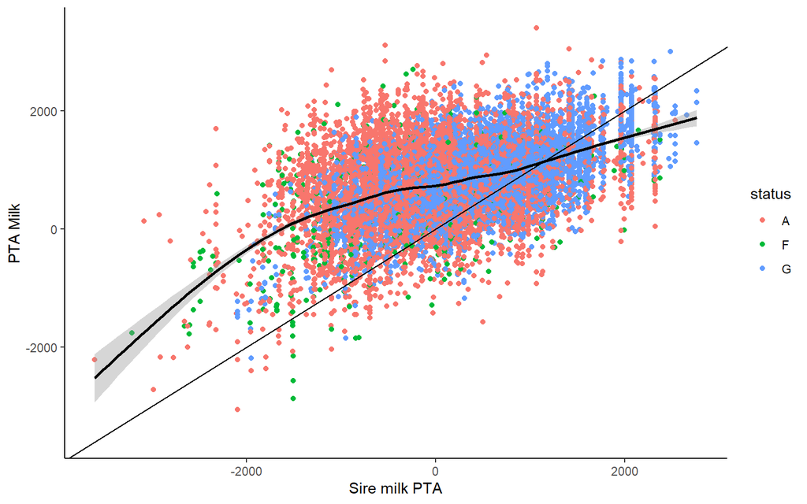

```r
naab_unique |>
  filter(!is.na(status)) |>
  ggplot(aes(x = pta_milk_sire, y = pta_milk)) +
  geom_jitter(aes(color = status)) +
  geom_smooth(color = "black") +
  geom_abline(slope = 1, intercept = 0) +
  theme_classic() +
  xlab("Sire milk PTA") + ylab("PTA Milk")
```

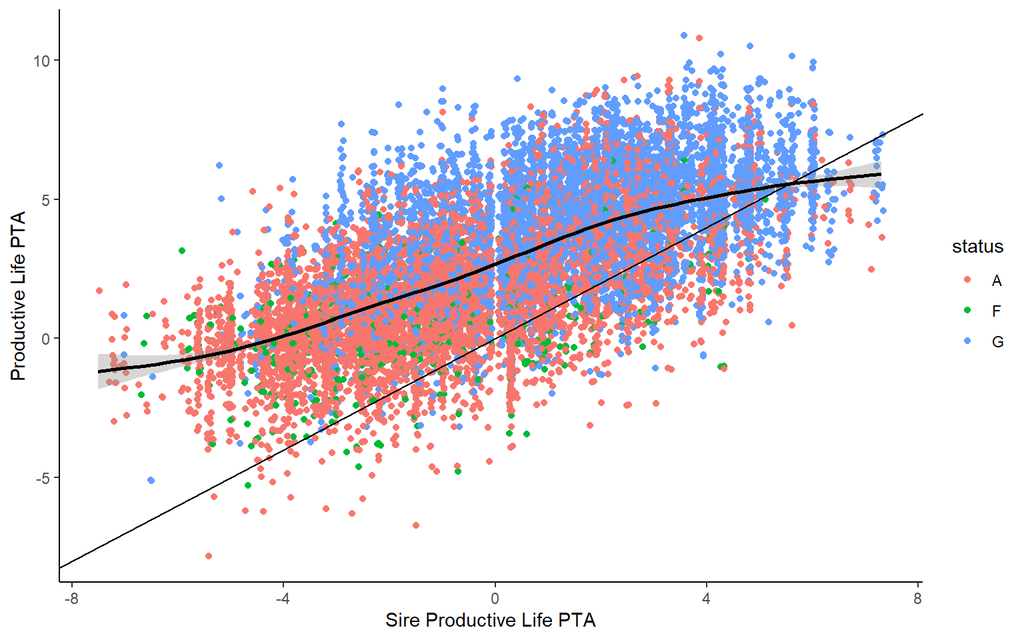

```r
naab_unique |>
  filter(!is.na(status)) |>
  ggplot(aes(x = pta_pl_sire, y = pta_pl)) +
  geom_jitter(aes(color = status)) +
  geom_smooth(color = "black") +
  geom_abline(slope = 1, intercept = 0) +
  theme_classic() +
  xlab("Sire Productive Life PTA") + ylab("Productive Life PTA")
```

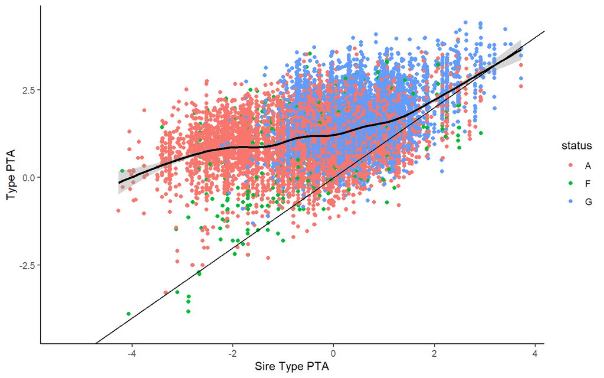

```r
naab_unique |>
  filter(!is.na(status)) |>
  ggplot(aes(x = pta_type_sire, y = pta_type)) +
  geom_jitter(aes(color = status)) +
  geom_smooth(color = "black") +
  geom_abline(slope = 1, intercept = 0) +
  theme_classic() +
  xlab("Sire Type PTA") + ylab("Type PTA")
```

```r
naab_unique |>
  select(c("reg_id", "pta_milk", "pta_fat_lb", "pta_protein_lb", "pta_scs",
           "pta_pl", "pta_dpr",  "pta_hcr", "pta_ccr", "pta_liv", "pta_type",
           "pta_gest_length", "pta_ketosis")) |>
  pivot_longer(cols = -reg_id,  names_to = "vars", values_to = "vals") ->
  bulls

naab_unique |>
  select(c("reg_id", "pta_milk_sire" , "pta_fat_lb_sire", "pta_protein_lb_sire",
           "pta_scs_sire", "pta_pl_sire", "pta_dpr_sire", "pta_hcr_sire",
           "pta_ccr_sire", "pta_liv_sire", "pta_type_sire",
           "pta_gest_length_sire", "pta_ketosis_sire")) |>
  rename(pta_milk = pta_milk_sire,
         pta_fat_lb = pta_fat_lb_sire,
         pta_protein_lb = pta_protein_lb_sire,
         pta_scs = pta_scs_sire,
         pta_pl = pta_pl_sire,
         pta_dpr = pta_dpr_sire,
         pta_hcr = pta_hcr_sire,
         pta_ccr = pta_ccr_sire,
         pta_liv = pta_liv_sire,
         pta_type = pta_type_sire,
         pta_gest_length = pta_gest_length_sire,
         pta_ketosis = pta_ketosis_sire) |>
  pivot_longer(cols = -reg_id, names_to = "vars", values_to = "vals_sire") ->
  sires

bulls <- left_join(bulls, sires, by = c("reg_id", "vars"))

bulls |>
  filter(!is.na(vals) & !is.na(vals_sire)) ->
  bulls
rm(sires)
```

```r
bulls_reg <- group_split(bulls, vars)
results <- map_dfr(bulls_reg, function(x) tidy(lm(vals ~ vals_sire, data = x)))
results |>
  filter(term != "(Intercept)") ->
  results

results$term <-  c("pta_ccr", "pta_dpr", "pta_fat_lb", "pta_gest_length",
                   "pta_hcr", "pta_ketosis", "pta_liv", "pta_milk", "pta_pl",
                   "pta_protein_lb", "pta_scs", "pta_type")
results |>
  data.frame()
```

| term | estimate | std.error | statistic | p.value |
| --- | --- | --- | --- | --- |
| pta_ccr | 0.4505573 | 0.007645436 | 58.93154 | 0.000000e+00 |
| pta_dpr | 0.3479808 | 0.005180255 | 67.17445 | 0.000000e+00 |
| pta_fat_lb | 0.4552093 | 0.005004419 | 90.96148 | 0.000000e+00 |
| pta_gest_length | 0.5427253 | 0.014181312 | 38.27046 | 4.282452e-255 |
| pta_hcr | 0.4097850 | 0.007192121 | 56.97692 | 0.000000e+00 |
| pta_ketosis | 0.7335383 | 0.011338327 | 64.69546 | 0.000000e+00 |
| pta_liv | 0.4692426 | 0.006820930 | 68.79451 | 0.000000e+00 |
| pta_milk | 0.3867895 | 0.005540666 | 69.80922 | 0.000000e+00 |
| pta_pl | 0.6219119 | 0.005670613 | 109.67279 | 0.000000e+00 |
| pta_protein_lb | 0.4089594 | 0.005139621 | 79.56995 | 0.000000e+00 |

[output cut: 2 more lines]

[output not shown]

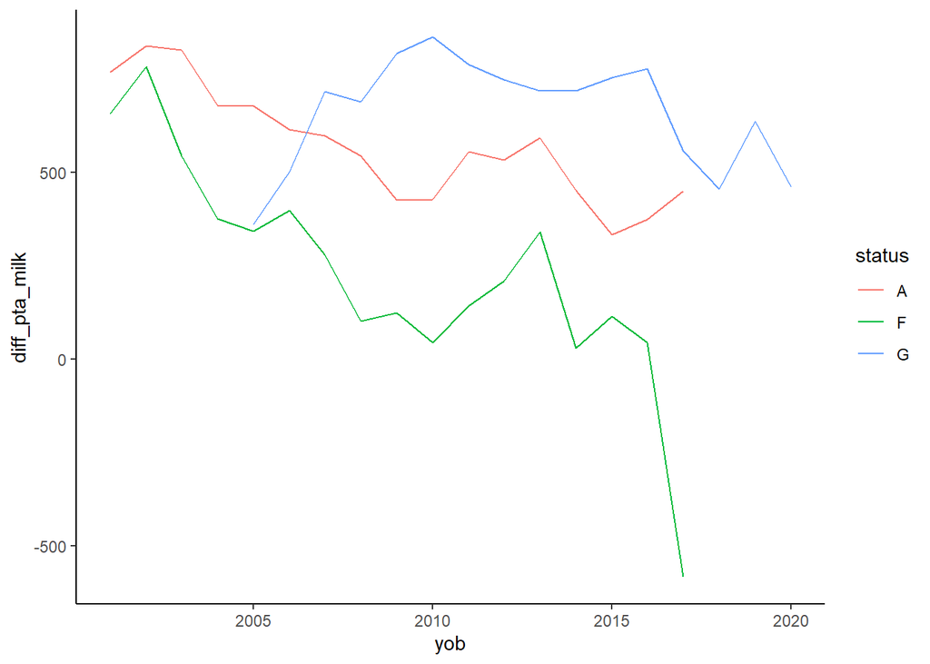

```r
naab_unique |>
  filter(!is.na(status)) |>
  mutate(diff_pta_milk = pta_milk - 0.5*pta_milk_sire) |>
  group_by(yob, status) |>
  summarise(diff_pta_milk = mean(diff_pta_milk, na.rm = TRUE)) |>
  filter(yob > 2000) |>
  ggplot(aes(x = yob, y = diff_pta_milk)) +
  geom_line(aes(color = status)) +
  theme_classic()
```

[output not shown]

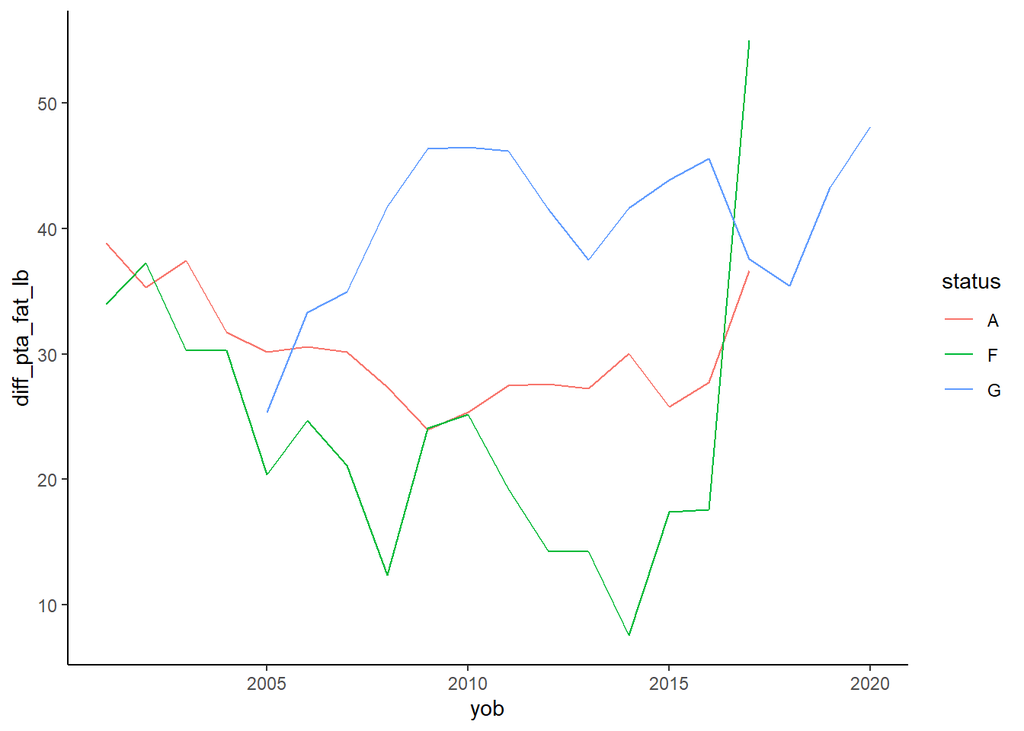

```r
naab_unique |>
  filter(!is.na(status)) |>
  mutate(diff_pta_fat_lb = pta_fat_lb - 0.5*pta_fat_lb_sire) |>
  group_by(yob, status) |>
  summarise(diff_pta_fat_lb = mean(diff_pta_fat_lb, na.rm = TRUE)) |>
  filter(yob > 2000) |>
  ggplot(aes(x = yob, y = diff_pta_fat_lb)) +
  geom_line(aes(color = status)) +
  theme_classic()
```

Number of daughters

```r
naab_unique |>
  rename(sire_id = sire_id.y) |>
  select(-sire_id.x) ->
  naab_unique
```

```r
naab_unique <- left_join(naab_unique, naab_old[, c("reg_id", "num_dtrs")],
                          by = join_by(sire_id == reg_id))
```

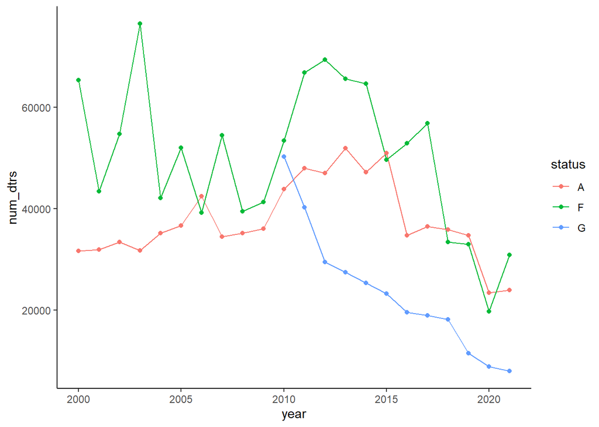

```r
naab_unique |>
  filter(!is.na(status)) |>
  group_by(year, status) |>
  summarise(num_dtrs = mean(num_dtrs, na.rm = TRUE)) |>
  ggplot(aes(x = year, y = num_dtrs, group = status)) +
  geom_line(aes(color = status)) +
  geom_point(aes(color = status)) +
  theme_classic()
```

Defining superstars

```r
connections <- naab[, c('reg_id', 'sire_id')] |>
  distinct(reg_id, .keep_all = TRUE)
names(connections) <- c("reg_id", "sire_id_g0")
connect <- naab[, c('reg_id', 'sire_id')] |>
  distinct(reg_id, .keep_all = TRUE)

cnt = 1
ix = 0

while(cnt != 0){
  connect_temp <- connect
  names(connect_temp) <- c(paste0('sire_id_g', as.character(ix)), paste0('sire_id_g', as.character(ix+1)))
  connections <- left_join(connections, connect_temp, by = paste0('sire_id_g', as.character(ix)))
  ix <- ix + 1
  cnt <- table(connections[, paste0('sire_id_g', as.character(ix))]) |>
    dim()
  print(cnt)
  rm(connect_temp)
}
```

```
## [1] 1831
## [1] 913
## [1] 520
## [1] 310
## [1] 187
## [1] 127
## [1] 89
## [1] 57
## [1] 35
## [1] 23
## [1] 13
## [1] 8
## [1] 5
## [1] 3
## [1] 1
## [1] 0
```

```r
connections <- connections[, -18]
rm(connect)
```

```r
connections <- left_join(connections, naab[, c("reg_id", "status")], by = "reg_id")
```

Pedigree of bulls

```r
connections |>
  select(-status) |>
  pivot_longer(sire_id_g0:sire_id_g15, names_to = "generation", values_to = "sire_id") |>
  filter(!is.na(sire_id)) |>
  separate(generation, into = c("type", "id", "gen"), sep = "_") |>
  select(-c(type, id)) |>
  separate(gen, into = c("g_var", "gen_num"), sep = 1) |>
  select(-g_var) %>%
  mutate(gen_num = as.numeric(gen_num)+1) ->
  pedigree
```

```r
son_counts <- left_join(son_counts, naab[, c("reg_id", "reg_name", "yob", "status")], by = join_by(sire_id == reg_id))

son_counts |>
  distinct(sire_id, .keep_all = TRUE) ->
  son_counts

son_counts |>
  mutate(reg_name = replace(reg_name, sire_id == "HOUSA000000819476", "Weber Burke Cyclone"),
         reg_name = replace(reg_name, sire_id == "HOCAN000000260753", "Rosafe Pearl Hannibal"),
         yob = replace(yob, sire_id == "HOCAN000000260753", 1953),
         reg_name = replace(reg_name, sire_id == "JEUSA000000488392", "Jester Standard Advancer"),
         reg_name = replace(reg_name, sire_id == "JEUSA000000399447", "Welcome Volunteer"),
         yob = replace(yob, sire_id == "JEUSA000000399447", 1942),
         reg_name = replace(reg_name, sire_id == "BSUSA000000090827", "Royal's Meridian of Lee's Hill"),
         yob = replace(yob, sire_id == "BSUSA000000090827", 1947),
         reg_name = replace(reg_name, sire_id == "BSUSA000000071151", "The Laird of Lee's Hill"),
         yob = replace(yob, sire_id == "BSUSA000000071151", 1945),
         reg_name = replace(reg_name, sire_id == "GUUSA000000470256", "Lyrene CH Wistar"),
         yob = replace(yob, sire_id == "GUUSA000000470256", 1950),
         reg_name = replace(reg_name, sire_id == "GUUSA000000458786", "Coldsprings B R Forcaster"),
         reg_name = replace(reg_name, sire_id == "JEDNK000000003951", "Brutus Syd"),
         yob = replace(yob, sire_id == "JEDNK000000003951", 1966),
         reg_name = replace(reg_name, sire_id == "AYUSA000000091883", "Balig Bruno Imp"),
         yob = replace(yob, sire_id == "AYUSA000000091883", 1947),
         reg_name = replace(reg_name, sire_id == "HOCAN000012532129", "Westcoast Fascinator"),
         yob = replace(yob, sire_id == "HOCAN000012532129", 2016),
         reg_name = replace(reg_name, sire_id == "AYCAN000109186197", "Guimond Yale-ET"),
         yob = replace(yob, sire_id == "AYCAN000109186197", 2015),
         reg_name = replace(reg_name, sire_id == "BSCHE120079480359", "Vetsch's Nesta Calvin-ET"),
         yob = replace(yob, sire_id == "BSCHE120079480359", 2009),
         reg_name = replace(reg_name, sire_id == "HOUSA000072102057", "Brandvale Stoic Damien-E"),
         yob = replace(yob, sire_id == "HOUSA000072102057", 2014),
         reg_name = replace(reg_name, sire_id == "AYCAN000105776780", "Chaluka Virgile-ET"),
         yob = replace(yob, sire_id == "AYCAN000105776780", 2009),
         reg_name = replace(reg_name, sire_id == "AYCAN000106853885", "Kellcrest Riesling"),
         yob = replace(yob, sire_id == "AYCAN000106853885", 2010),
         reg_name = replace(reg_name, sire_id == "AYCAN000109734076", "Cock Rond Imagine"),
         yob = replace(yob, sire_id == "AYCAN000109734076", 2016),
         reg_name = replace(reg_name, sire_id == "AYUSA000000111157", "Selwood Cora's Burton"),
         yob = replace(yob, sire_id == "AYUSA000000111157", 1949),
         reg_name = replace(reg_name, sire_id == "AYUSA000000111157", "Selwood Cora's Burton"),
         yob = replace(yob, sire_id == "AYUSA000000111157", 1949),
         reg_name = replace(reg_name, sire_id == "BSCHE120119702885", "Lennox"),
         yob = replace(yob, sire_id == "BSCHE120119702885", 2015),
         reg_name = replace(reg_name, sire_id == "GUUSA000097001421", "Walnut Ridge Prince Charming"),
         reg_name = replace(reg_name, sire_id == "HOCAN000012529310", "Progenesis Padawan"),
         yob = replace(yob, sire_id == "HOCAN000012529310", 2016),
         reg_name = replace(reg_name, sire_id == "HODEU000539675034", "Hotspot P"),
         yob = replace(yob, sire_id == "HODEU000539675034", 2017),
         reg_name = replace(reg_name, sire_id == "HONLD000754797988", "Delta Leader P"),
         yob = replace(yob, sire_id == "HONLD000754797988", 2016),
         reg_name = replace(reg_name, sire_id == "HOUSA000142925043", "Mr Sunrose Saturn"),
         yob = replace(yob, sire_id == "HOUSA000142925043", 2013),
         reg_name = replace(reg_name, sire_id == "JEDNK000000303812", "VJ Fihl Husky Hihl"),
         yob = replace(yob, sire_id == "JEDNK000000303812", 2012),
         reg_name = replace(reg_name, sire_id == "JEDNK000000304129", "VJ Dongsgaarden Husky haley"),
         yob = replace(yob, sire_id == "JEDNK000000304129", 2015),
         reg_name = replace(reg_name, sire_id == "JEDNK000000304223", "VJ Lobo"),
         yob = replace(yob, sire_id == "JEDNK000000304223", 2015),
         reg_name = replace(reg_name, sire_id == "JEDNK000000304229", "ISDK VJ Mosegaard Hilario Haare"),
         yob = replace(yob, sire_id == "JEDNK000000304229", 2015),
         reg_name = replace(reg_name, sire_id == "JEUSA000000486937", "Brampton W R Lord Clair"),
         yob = replace(yob, sire_id == "JEUSA000000486937", 1945)) ->
  son_counts
```

```r
pctile(naab_old$num_dtrs, probs = seq(0, 10, 1)/10, na.rm = TRUE)
```

```
##    0%   10%   20%   30%   40%   50%   60%   70%   80%   90%  100%
##     0    19    59    84   104   129   175   343   924  3379 99999
```

```r
naab_old |>
  mutate(superstar = ifelse(num_dtrs > 3300, 1, 0)) ->
  naab_old
```

```r
naab_old |>
  filter(superstar == 1) |>
  select(reg_id) ->
  superstars

pedigree |>
  mutate(superstar = ifelse(sire_id %in% superstars$reg_id, 1, 0),
         weight = 2^(-(gen_num+1))) ->
  pedigree
```

Genomic tested bulls are NOT more related to “superstars” than active bulls!

1. Define superstars by number of daughters

```r
pedigree |>
  group_by(reg_id) |>
  summarise(score = sum(weight*superstar)) ->
  scores

scores <- left_join(scores, naab_old[, c("reg_id", "status", "yob")], by = "reg_id")
scores <- left_join(scores, naab_unique[, c("reg_id", "status", "yob")], by = "reg_id")

scores |>
  mutate(status = ifelse(is.na(status.y), status.x, status.y),
         yob = ifelse(is.na(yob.y), yob.x, yob.y)) |>
  select(-c(status.x, status.y, yob.x, yob.y)) ->
  scores


scores |>
  filter(!is.na(status)) |>
  group_by(status) |>
  summarise(score_sum = sum(score, na.rm = TRUE),
            score_mean = mean(score, na.rm = TRUE),
            N = n())
```

| status | score_sum | score_mean | N |
| --- | --- | --- | --- |
| A | 3578.18506 | 0.5037569 | 7103 |
| F | 421.36780 | 0.4980707 | 846 |
| G | 3021.06546 | 0.4882925 | 6187 |
| I | 11723.26758 | 0.4323058 | 27118 |
| N | 56.35760 | 0.3757174 | 150 |
| P | 16.80402 | 0.2897244 | 58 |

**Problem**: `num_dtrs` is available only for active sires, and its weight decreases after 2015.

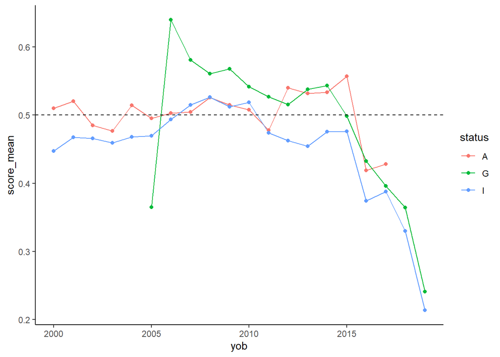

```r
scores |>
  filter(status %in% c("A", "G", "I") & yob > 1999 & yob < 2020) |>
  group_by(status, yob) |>
  summarise(score_mean = mean(score, na.rm = TRUE)) |>
  ggplot(aes(x = yob, y = score_mean, group = status)) +
  geom_line(aes(color = status)) +
  geom_point(aes(color = status)) +
  geom_hline(yintercept = 0.5, color = "black", linetype  = 2) +
  theme_classic()
```

```r
pedigree |>
  mutate(superstar_alt = ifelse(sire_id %in% son_counts$sire_id, 1, 0)) ->
  pedigree

pedigree |>
  group_by(reg_id) |>
  summarise(score_alt = sum(weight*superstar_alt)) ->
  scores_alt

scores_alt <- left_join(scores_alt, naab_old[, c("reg_id", "status", "yob")], by = "reg_id")
scores_alt <- left_join(scores_alt, naab_unique[, c("reg_id", "status", "yob")], by = "reg_id")

scores_alt |>
  mutate(status = ifelse(is.na(status.y), status.x, status.y),
         yob = ifelse(is.na(yob.y), yob.x, yob.y)) |>
  select(-c(status.x, status.y, yob.x, yob.y)) ->
  scores_alt


scores_alt |>
  filter(!is.na(status)) |>
  group_by(status) |>
  summarise(score_sum = sum(score_alt, na.rm = TRUE),
            score_mean = mean(score_alt, na.rm = TRUE),
            N = n())
```

| status | score_sum | score_mean | N |
| --- | --- | --- | --- |
| A | 4182.12158 | 0.5887824 | 7103 |
| F | 496.29410 | 0.5866360 | 846 |
| G | 3613.73511 | 0.5840852 | 6187 |
| I | 14405.62039 | 0.5312199 | 27118 |
| N | 84.09116 | 0.5606078 | 150 |
| P | 25.79898 | 0.4448100 | 58 |

But the proportion of relatedness is variable in time

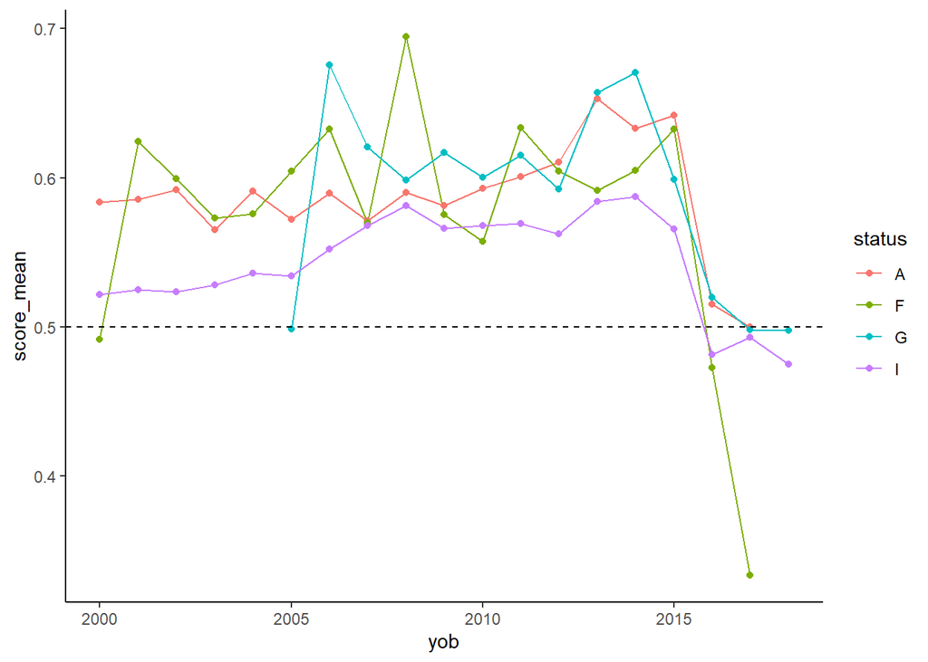

```r
scores_alt |>
  filter(status %in% c("A", "G", "F", "I") & yob > 1999 & yob < 2019) |>
  group_by(status, yob) |>
  summarise(score_mean = mean(score_alt, na.rm = TRUE)) |>
  ggplot(aes(x = yob, y = score_mean, group = status)) +
  geom_line(aes(color = status)) +
  geom_point(aes(color = status)) +
  geom_hline(yintercept = 0.5, color = "black", linetype  = 2) +
  theme_classic()
```

```r
naab_old |>
  separate(naab_code, into = c("primary_stud_code", "rest"), sep = 3, remove = FALSE) |>
  mutate(primary_stud_code = as.numeric(primary_stud_code)) |>
  select(-rest) ->
  naab_old
```

```r
naab_old <- left_join(naab_old, companies, by = "primary_stud_code")
```

```r
naab_old|>
  filter(reg_id %in% superstars$reg_id) ->
  naab_super

naab_super |>
  mutate(parent_company = ifelse(is.na(parent_company), company_name, parent_company)) |>
  tab(parent_company)
```

```
##
## parent~y │    Freq.  Percent     Cum.
## ─────────┼────────────────────────────
## A.I. T~. │        4     0.09     0.09
## ABS Gl~l │      516    12.23    12.32
## Aberek~. │        2     0.05    12.37
## Ag-Lin~. │        1     0.02    12.39
## All We~s │        1     0.02    12.42
## Alpens~o │        5     0.12    12.54
## Alta G~s │      327     7.75    20.28
## Alta G~n │        9     0.21    20.50
## Androg~s │        5     0.12    20.62
## Bayern~H │       41     0.97    21.59
## CBS Ge~. │        1     0.02    21.61
## CIA de~O │        1     0.02    21.64
##   COOPEX │       11     0.26    21.90
## CRV Ho~g │      150     3.55    25.45
## Centra~s │        3     0.07    25.52
## Cogent~. │        5     0.12    25.64
## Cooper~O │        3     0.07    25.71
## Cooper~t │        1     0.02    25.73
## Curtis~s │       27     0.64    26.37
## Depend~s │        2     0.05    26.42
## EVA Jura │        4     0.09    26.52
## EastGe~. │       14     0.33    26.85
## El Tor~r │        1     0.02    26.87
## Excels~s │        7     0.17    27.04
## FABA S~e │        9     0.21    27.25
## GB Gen~L │        2     0.05    27.30
## GEN'IA~T │       27     0.64    27.94
## Galaxi~. │        1     0.02    27.96
## Genes ~n │        7     0.17    28.13
## Geneti~n │        1     0.02    28.15
## Geneti~d │        7     0.17    28.32
## Geneti~. │        2     0.05    28.36
##    Genex │      550    13.03    41.40
## Geno A~r │       41     0.97    42.37
## German~) │        3     0.07    42.44
## Global~. │        1     0.02    42.46
## Global~C │       31     0.73    43.20
```

[output cut: 24 more lines]

```
## Stgene~s │       10     0.24    84.48
## Swissg~n │       16     0.38    84.86
## Synetics │       13     0.31    85.17
## Triple~s │       39     0.92    86.09
## Triple~s │        1     0.02    86.11
## Union ~) │       13     0.31    86.42
## Univer~. │        4     0.09    86.52
##     Urus │       18     0.43    86.94
## VOST (~. │        1     0.02    86.97
## Viking~s │       88     2.09    89.05
##  WESTGEN │       10     0.24    89.29
## WEU (W~) │        1     0.02    89.31
## Xeneti~. │        1     0.02    89.34
## Zooser~. │        1     0.02    89.36
##       NA │      449    10.64   100.00
```

Most missing animals are from outside the US

```r
naab_super |>
  filter(is.na(company_name)) |>
  tab(country)
```

```
##
## country │    Freq.  Percent     Cum.
## ────────┼────────────────────────────
##     AUS │        4     0.89     0.89
##     AUT │       14     3.12     4.01
##     CAN │        2     0.45     4.45
##     CHE │        1     0.22     4.68
##     CZE │        2     0.45     5.12
##     DEU │      108    24.05    29.18
##     DNK │       23     5.12    34.30
##     ESP │        3     0.67    34.97
##     FIN │       29     6.46    41.43
##     FRA │       67    14.92    56.35
##     GBR │        2     0.45    56.79
##     IRL │        1     0.22    57.02
##     ITA │        6     1.34    58.35
##     NLD │       28     6.24    64.59
##     NOR │       60    13.36    77.95
##     NZL │       59    13.14    91.09
##     SWE │       22     4.90    95.99
##     USA │       18     4.01   100.00
```

```r
naab_super |>
  mutate(parent_company = ifelse(is.na(parent_company), company_name, parent_company)) |>
  filter(!is.na(parent_company) & yob > 2000) |>
  tab(yob, parent_company)
```

```
##
##      yob │ parent~y │    Freq.  Percent     Cum.
## ─────────┼──────────┼────────────────────────────
##     2001 │ ABS Gl~l │       15     0.78     0.78
##     2001 │ Alpens~o │        1     0.05     0.83
##     2001 │ Alta G~s │       20     1.04     1.88
##     2001 │ Bayern~H │        3     0.16     2.03
##     2001 │   COOPEX │        1     0.05     2.08
##     2001 │ CRV Ho~g │        4     0.21     2.29
##     2001 │ Depend~s │        1     0.05     2.34
##     2001 │ FABA S~e │        2     0.10     2.45
##     2001 │ GEN'IA~T │        1     0.05     2.50
##     2001 │    Genex │       13     0.68     3.18
##     2001 │ Geno A~r │        3     0.16     3.34
##     2001 │ Global~C │        1     0.05     3.39
```

[output cut: 282 more lines]

```r
pedigree |>
  group_by(sire_id) |>
  summarise(w = sum(weight)) |>
  arrange(desc(w))
```

| sire_id | w |
| --- | --- |
| HOUSA000122358313 | 328.3046875 |
| HOUSA000001491007 | 282.5850830 |
| HOUSA000002290977 | 264.1953125 |
| HO840003006972816 | 261.7031250 |
| HOUSA000060597003 | 259.5390625 |
| HOCAN000000352790 | 250.1191406 |
| HOUSA000002183007 | 238.0273438 |
| HOUSA000001929410 | 228.6108398 |
| HOUSA000001427381 | 223.4105835 |
| HOGBR000000598172 | 221.5937500 |

[output cut: 5382 more lines]

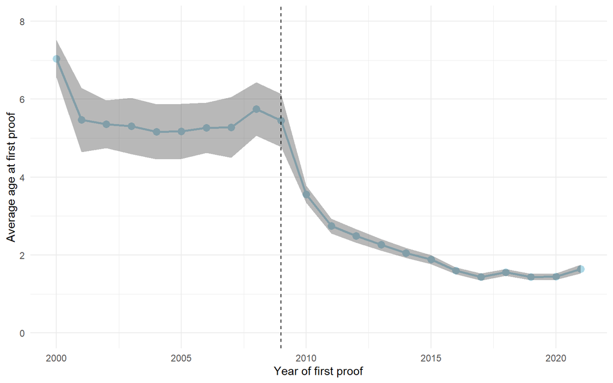

```r
alpha <- qnorm(0.99)
naab_aiss |>
  group_by(reg_id) |>
  arrange(period) |>
  slice_head(n = 1) |>
  ungroup() |>
  group_by(year_proof) |>
  summarise(age_m = mean(age),
            age_sd = mean(age),
            N = n()) |>
  ggplot(aes(x = year_proof, y = age_m)) +
  geom_point(color = "lightblue", size = 3) +
  geom_line(color = "lightblue", linewidth = 1) +
  geom_ribbon(aes(ymin = age_m-alpha*age_sd/sqrt(N),
                  ymax = age_m+alpha*age_sd/sqrt(N)),
              alpha = 0.35) +
  theme_minimal() +
  geom_vline(xintercept =  2009, linetype = 2) +
  xlab("Year of first proof") +
  ylab("Average age at first proof") +
  scale_x_continuous(breaks = seq(2000, 2020, 5)) +
  ylim(0, 8)
```

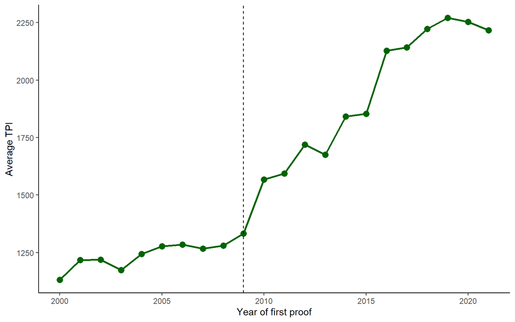

```r
naab_aiss |>
  group_by(reg_id) |>
  arrange(period) |>
  slice_head(n = 1) |>
  ungroup() |>
  group_by(year_proof) |>
  summarise(TPI = mean(TPI, na.rm = TRUE)) |>
  ggplot(aes(x = year_proof, y = TPI)) +
  geom_point(color = "darkgreen", size = 3) +
  geom_line(color = "darkgreen", linewidth = 1) +
  theme_classic() +
  geom_vline(xintercept =  2009, linetype = 2) +
  xlab("Year of first proof") +
  ylab("Average TPI") +
  scale_x_continuous(breaks = seq(2000, 2020, 5))
```